# Mucosal microbiota alterations in primary sclerosis cholangitis persist after liver transplantation and are associated with clinical features independently of geography

Clinical analysis

# 1 Introduction

Following a comprehensive analysis of the microbiome data, we extended our investigation to clinical parameters, incorporating the previously computed Microbial Dysbiosis Index (MDI). Our analysis focused on evaluating the relationships between the MDI, individual microbial taxa, and relevant clinical variables.

Specifically, this script includes multiple statistical and visualization approaches to explore these associations. First, we present MDI distributions across different groups using boxplots and ROC curves to evaluate the discriminatory power of the MDI.

Additionally, we analyze the correlation between alpha diversity and MDI to assess whether overall microbiome diversity is linked to dysbiosis severity. These relationships are further explored through correlation analyses, where we visualize associations between MDI and clinical variables using heatmaps. Finally, we assess the correlation between specific PSC-associated bacterial taxa and clinical parameters, highlighting potential microbial biomarkers for disease progression and severity.

*Importing libraries and custom functions built for this analysis*

```r
source("custom_functions.R")
```

# 2 Import clinical data

## 2.1 CZ

```r
# clinical metadata
metadata_clinical <- read.csv("../../data/clinical_data/clinical_metadata_cz.csv")
metadata_clinical$PatientID <- as.character(metadata_clinical$PatientID)

# DYSBIOSIS
metadata_dysbiosis <- read.csv("../../data/clinical_data/dysbiosis_metadata.csv") %>%
  dplyr::filter(Country=="CZ")

# ALPHA DIVERSITY
metadata_alpha_ileum <- read.csv(
  "../results/Q1/alpha_diversity/alpha_indices_terminal_ileum.csv") %>%
  dplyr::filter(Country=="CZ")

metadata_alpha_colon <- read.csv(
  "../results/Q1/alpha_diversity/alpha_indices_colon.csv") %>%
  dplyr::filter(Country=="CZ")

metadata_alpha <- rbind(metadata_alpha_ileum,metadata_alpha_colon) %>%
  mutate(PatientID=Patient) %>%
  dplyr::select(-c(Patient, Group))

# MERGING
metadata_cz <- full_join(metadata_clinical, metadata_dysbiosis, by=c("SampleID","Matrix","PatientID","Group","Country"))

metadata_cz <- full_join(metadata_cz, metadata_alpha, by=c("SampleID","PatientID","Country"))

metadata_cz$Group <- factor(metadata_cz$Group,levels = c("healthy","pre_ltx","non-rPSC","rPSC"))
```

## 2.2 NO

```r
# clinical metadata
metadata_clinical <- read.csv("../../data/clinical_data/clinical_metadata_no.csv")
metadata_clinical %<>% mutate(PatientID=subjectid,
                              Matrix=segment) %>%
  dplyr::select(-subjectid,-segment)
metadata_clinical$PatientID <- as.character(paste0("NO_",metadata_clinical$PatientID))

# DYSBIOSIS
metadata_dysbiosis <- read.csv("../../data/clinical_data/dysbiosis_metadata.csv") %>%
  dplyr::filter(Country=="NO")  %>%
  dplyr::select(-c(Patient))

# ALPHA DIVERSITY
metadata_alpha_ileum <- read.csv(
  "../results/Q1/alpha_diversity/alpha_indices_terminal_ileum.csv") %>%
  dplyr::filter(Country=="NO")

metadata_alpha_colon <- read.csv(
  "../results/Q1/alpha_diversity/alpha_indices_colon.csv") %>%
  dplyr::filter(Country=="NO")

metadata_alpha <- rbind(metadata_alpha_ileum,metadata_alpha_colon) %>%
  mutate(PatientID=Patient) %>%
  dplyr::select(-c(Patient, Group))

# MERGING
metadata_no <- full_join(metadata_clinical, metadata_dysbiosis, by=c("SampleID","Matrix","PatientID","Group","Country"))

metadata_no <- full_join(metadata_no, metadata_alpha, by=c("SampleID","PatientID","Country"))

metadata_no$Group <- factor(metadata_no$Group,levels = c("healthy","pre_ltx","non-rPSC","rPSC"))
```

## 2.3 Merging metadata

```r
metadata_cz %<>% dplyr::mutate(Calprotectin=Fecal.calprotectin,
                             AOM=AOM_score,
                             APRI=APRI_score,
                             FIB4=FIB4_score) %>%
  dplyr::select(SampleID,Matrix,PatientID,Group,Country,Bilirubin,ALP,Calprotectin,
                MAYO_PSC,AOM,APRI,FIB4,Platelets,AST,Creatinine,
                Albumin,ALT,PSC_IBD,GGT,INR,Albumin,Nancy_max,eMAYO,MAYO_dai,
                dys_unfiltered_asv,dys_unfiltered_genus,
                dys_filtered_asv,dys_filtered_genus,
                Observe,Shannon,Simpson,Pielou)

metadata_no %<>% dplyr::mutate(Platelets=TRC,
                             Creatinine=Kreatinin,
                             MAYO_PSC=Mayo_score,
                             AST=ASAT/60,
                             ALT=ALAT/60,
                             PSC_IBD=IBD,
                             Bilirubin=Bilirubin*17.1,
                             ALP=ALP/60,
                             Albumin=Albumin*10) %>%
  dplyr::mutate(PSC_IBD = case_when(
      PSC_IBD == "no_ibd" ~ "0",
      PSC_IBD == "ibd" ~ "1",
      TRUE ~ Group  # Keep other values as is
    )) %>%
  dplyr::select(SampleID,Matrix,PatientID,Group,Country,Bilirubin,ALP,Calprotectin,
                MAYO_PSC,AOM,APRI,FIB4,Platelets,AST,Creatinine,
                Albumin,ALT,PSC_IBD,
                dys_unfiltered_asv,dys_unfiltered_genus,
                dys_filtered_asv,dys_filtered_genus,
                Observe,Shannon,Simpson,Pielou)

metadata_final <- merge(metadata_cz,metadata_no,all = TRUE)
```

```r
variables <- c("PatientID", "Group", "Country",
               "Bilirubin", "Albumin",
               "ALP", "Platelets",
               "Calprotectin",
               "MAYO_PSC","AOM",
               "APRI","INR",
               "FIB4",
               "Creatinine",
               "ALT","AST","GGT",
               "Nancy_max","eMAYO","MAYO_dai","PSC_IBD")
```

```r
metadata_final$Calprotectin[metadata_final$Group=="healthy"] <- NA
metadata_final$Calprotectin[metadata_final$Calprotectin==">6000"] <- 6000
metadata_final$Calprotectin <- as.numeric(metadata_final$Calprotectin)

metadata_ileum <- metadata_final %>% subset(Matrix=="TI") %>% as.data.frame()
metadata_colon <- metadata_final %>% subset(Matrix!="TI") %>% as.data.frame()

metadata_for_boxplots <- metadata_final[,variables] %>%
  group_by(PatientID) %>%
  distinct(PatientID, .keep_all = TRUE) %>%
  as.data.frame()
```

# 3 Import microbiome data

## 3.1 Data Import

Importing ASV, taxa and metadata tables for both Czech and Norway samples.

*Czech*

```r
path = "../../data/analysis_ready_data/ikem/"
asv_tab_ikem <- as.data.frame(fread(file.path(path,"asv_table_ikem.csv"),
                                    check.names = FALSE))
taxa_tab_ikem <- as.data.frame(fread(file.path(path,"taxa_table_ikem.csv"),
                                     check.names = FALSE))
metadata_ikem <- as.data.frame(fread(file.path(path,"metadata_ikem.csv"),
                                     check.names = FALSE))
```

*Norway*

```r
path = "../../data/analysis_ready_data/norway/"
asv_tab_norway <- as.data.frame(fread(file.path(path,"asv_table_norway.csv"),
                                    check.names = FALSE))
taxa_tab_norway <- as.data.frame(fread(file.path(path,"taxa_table_norway.csv"),
                                     check.names = FALSE))
metadata_norway <- as.data.frame(fread(file.path(path,"metadata_norway.csv"),
                                     check.names = FALSE))
```

## 3.2 Spliting to segments

*Terminal ileum*

```r
ileum_data <- merging_data(asv_tab_1=asv_tab_ikem,
                           asv_tab_2=asv_tab_norway,
                           taxa_tab_1=taxa_tab_ikem,
                           taxa_tab_2=taxa_tab_norway,
                           metadata_1=metadata_ikem,
                           metadata_2=metadata_norway,
                           segment="TI",Q="clinical")
```

```
Removing 1498 ASV(s)
```

```
Removing 1834 ASV(s)
```

```
Merging at ASV level
```

```
Finding inconsistencies in taxonomy, trying to keep the ones that have better taxonomy assignment
```

```r
ileum_asv_tab <- ileum_data[[1]]
ileum_taxa_tab <- ileum_data[[2]]
ileum_metadata <- ileum_data[[3]]
```

*Colon*

```r
colon_data <- merging_data(asv_tab_1=asv_tab_ikem,
                           asv_tab_2=asv_tab_norway,
                           taxa_tab_1=taxa_tab_ikem,
                           taxa_tab_2=taxa_tab_norway,
                           metadata_1=metadata_ikem,
                           metadata_2=metadata_norway,
                           segment="colon",Q="clinical")
```

```
Removing 739 ASV(s)
```

```
Removing 266 ASV(s)
```

```
Merging at ASV level
```

```
Finding inconsistencies in taxonomy, trying to keep the ones that have better taxonomy assignment
```

```r
colon_asv_tab <- colon_data[[1]]
colon_taxa_tab <- colon_data[[2]]
colon_metadata <- colon_data[[3]]
```

## 3.3 Filtering

Rules: - sequencing depth > 10000 - nearZeroVar() with default settings

**Terminal ileum**

*Sequencing depth*

```r
data_filt <- seq_depth_filtering(ileum_asv_tab,
                                 ileum_taxa_tab,
                                 ileum_metadata,
                                 seq_depth_threshold = 10000)
```

```
Removing 131 ASV(s)
```

```r
filt_ileum_asv_tab <- data_filt[[1]]; alpha_ileum_asv_tab <- filt_ileum_asv_tab
filt_ileum_taxa_tab <- data_filt[[2]]; alpha_ileum_taxa_tab <- filt_ileum_taxa_tab
filt_ileum_metadata <- data_filt[[3]]; alpha_ileum_metadata <- filt_ileum_metadata

seq_step <- dim(filt_ileum_asv_tab)[1]
```

*NearZeroVar*

```r
data_filt <- nearzerovar_filtering(filt_ileum_asv_tab,
                                   filt_ileum_taxa_tab,
                                   filt_ileum_metadata)

filt_ileum_asv_tab <- data_filt[[1]]
filt_ileum_taxa_tab <- data_filt[[2]]
nearzero_step <- dim(filt_ileum_asv_tab)[1]
```

**Colon**

*Sequencing depth*

```r
data_filt <- seq_depth_filtering(colon_asv_tab,
                                 colon_taxa_tab,
                                 colon_metadata,
                                 seq_depth_threshold = 10000)
```

```
Removing 75 ASV(s)
```

```r
filt_colon_asv_tab <- data_filt[[1]]; alpha_colon_asv_tab <- filt_colon_asv_tab
filt_colon_taxa_tab <- data_filt[[2]]; alpha_colon_taxa_tab <- filt_colon_taxa_tab
filt_colon_metadata <- data_filt[[3]]; alpha_colon_metadata <- filt_colon_metadata

seq_step <- dim(filt_colon_asv_tab)[1]
```

*NearZeroVar*

```r
data_filt <- nearzerovar_filtering(filt_colon_asv_tab,
                                   filt_colon_taxa_tab,
                                   filt_colon_metadata)

filt_colon_asv_tab <- data_filt[[1]]
filt_colon_taxa_tab <- data_filt[[2]]
nearzero_step <- dim(filt_colon_asv_tab)[1]
```

*Check zero depth*

```r
data_filt <- check_zero_depth(filt_colon_asv_tab,
                              filt_colon_taxa_tab,
                              filt_colon_metadata)

filt_colon_asv_tab <- data_filt[[1]];
filt_colon_taxa_tab <- data_filt[[2]];
filt_colon_metadata <- data_filt[[3]];
```

# 4 MDI

## 4.1 Terminal ileum

### 4.1.1 Boxplots

#### 4.1.1.1 PSC groups

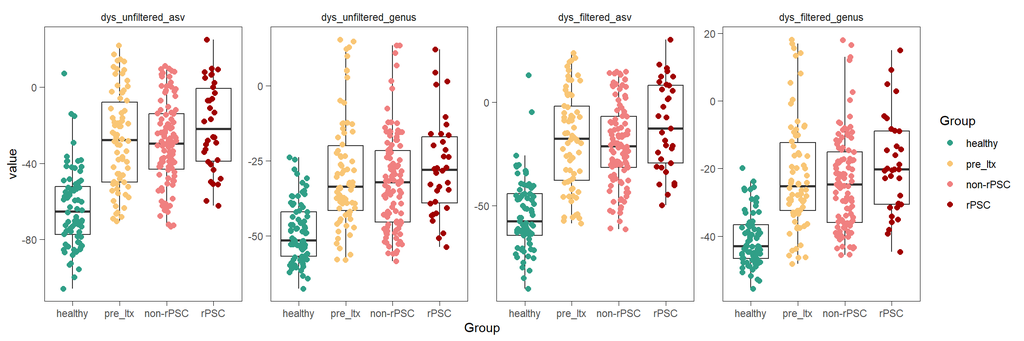

```r
metadata_ileum_melted <- melt(metadata_ileum %>%
                                dplyr::select("Group",
                                              "dys_unfiltered_asv",
                                              "dys_unfiltered_genus",
                                              "dys_filtered_asv",
                                              "dys_filtered_genus"))
p_il <- ggplot(metadata_ileum_melted) +
  geom_boxplot(aes(x=Group, y=value),outliers = FALSE) +
  geom_jitter(width = 0.2,height = 0,aes(x=Group, y=value, color=Group),
              size=2) +
  facet_wrap(~variable, ncol = 4,scales = "free") +
  theme_minimal() +
    theme(panel.border = element_rect(color = "black", fill = NA, size = 0),
          axis.ticks.x = element_line(size=0.3,color = "black"),
          axis.ticks.y = element_line(size=0.3,color="black"),
          axis.ticks.length = unit(4,"pt"),
          panel.grid = element_blank()) +
  scale_fill_manual(values=c("#309f87","#f9c675","#F08080","#A00000")) +
  scale_color_manual(values=c("#309f87","#f9c675","#F08080","#A00000"))

p_il
```

**FILTERED GENUS**

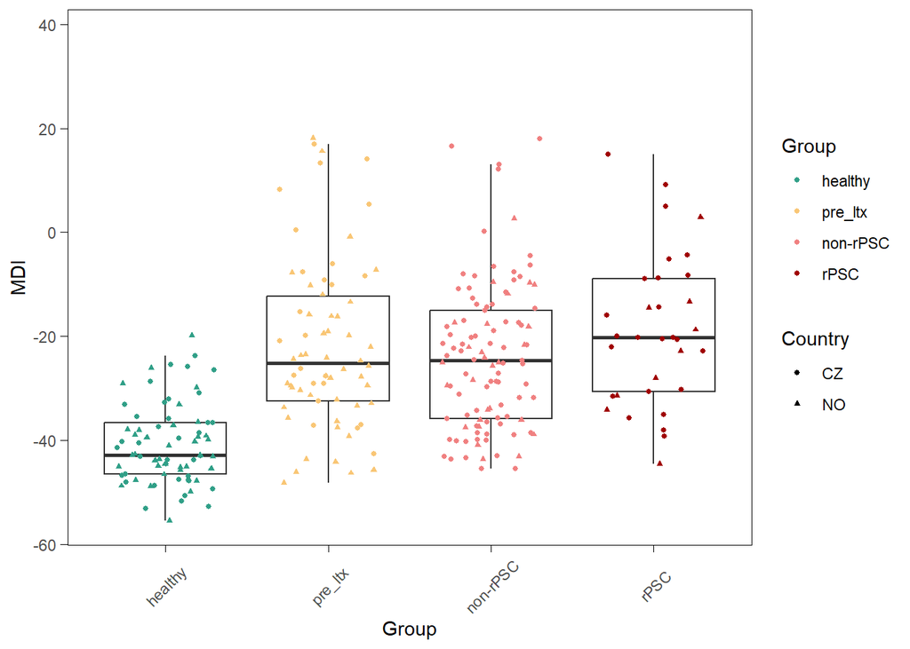

```r
dys_limit <- max(metadata_ileum$dys_filtered_genus,na.rm = TRUE) + 1.1*max(metadata_ileum$dys_filtered_genus,na.rm = TRUE)
dys_min_limit <-  min(metadata_ileum$dys_filtered_genus)

p_il_dys_genus <- ggplot(metadata_ileum %>%
                            mutate(`MDI`=dys_filtered_genus)) +
  geom_boxplot(aes(x=Group, y=`MDI`),outliers = FALSE) +
  geom_jitter(width = 0.3,height = 0,
              aes(x=Group, y=`MDI`, color=Group,shape=Country),
              size=1) +
  theme_minimal() +
    theme(panel.border = element_rect(color = "black", fill = NA, size = 0),
          axis.ticks.x = element_line(size=0.3,color = "black"),
          axis.ticks.y = element_line(size=0.3,color="black"),
          axis.ticks.length = unit(4,"pt"),
          panel.grid = element_blank()) +
  ylim(dys_min_limit,dys_limit) +
  scale_fill_manual(values=c("#309f87","#f9c675","#F08080","#A00000")) +
  scale_color_manual(values=c("#309f87","#f9c675","#F08080","#A00000")) +
  theme(axis.text.x = element_text(angle = 45,vjust = 0.5))

p_il_dys_genus
```

#### 4.1.1.2 IBD

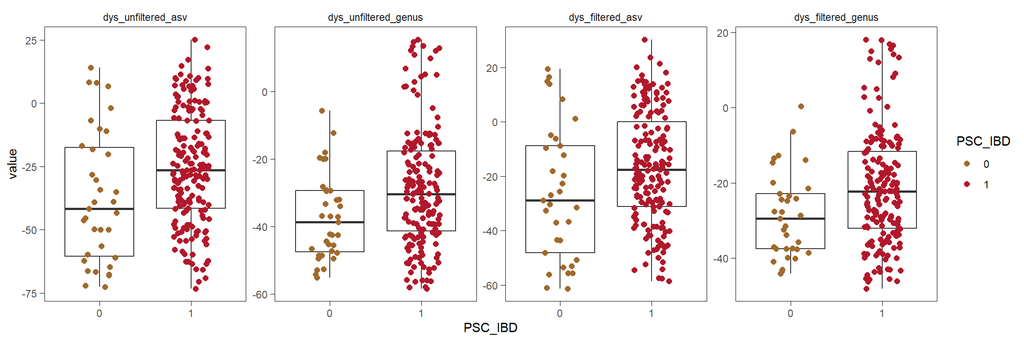

```r
metadata_ileum_melted <- melt(metadata_ileum %>%
                                dplyr::filter(PSC_IBD %in% c(0,1)) %>%
                                dplyr::select("PSC_IBD",
                                              "dys_unfiltered_asv",
                                              "dys_unfiltered_genus",
                                              "dys_filtered_asv",
                                              "dys_filtered_genus"))
p_il <- ggplot(metadata_ileum_melted) +
  geom_boxplot(aes(x=PSC_IBD, y=value),outliers = FALSE) +
  geom_jitter(width = 0.2,height = 0,aes(x=PSC_IBD, y=value, color=PSC_IBD),
              size=2) +
  facet_wrap(~variable, ncol = 4,scales = "free") +
  theme_minimal() +
    theme(panel.border = element_rect(color = "black", fill = NA, size = 0),
          axis.ticks.x = element_line(size=0.3,color = "black"),
          axis.ticks.y = element_line(size=0.3,color="black"),
          axis.ticks.length = unit(4,"pt"),
          panel.grid = element_blank()) +
  scale_fill_manual(values=c("#A06A2C", "#B2182B")) +
  scale_color_manual(values=c("#A06A2C", "#B2182B"))

p_il
```

**FILTERED GENUS**

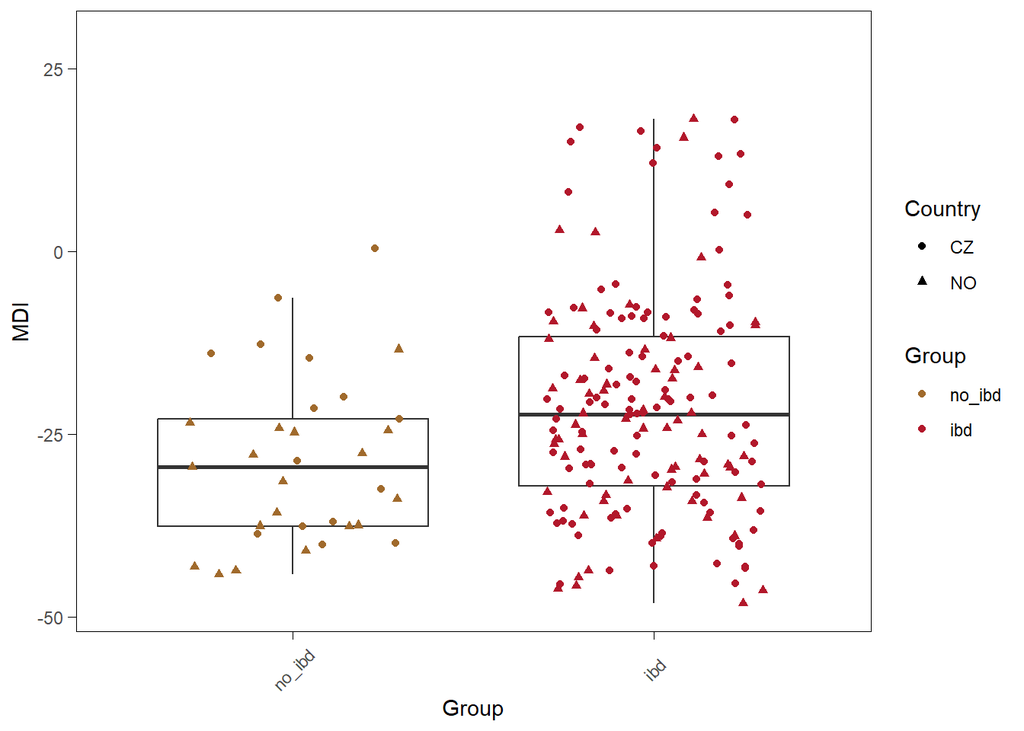

```r
metadata_ileum_for_plot <- metadata_ileum %>%
                                dplyr::filter(PSC_IBD %in% c(0,1)) %>%
  mutate(Group=case_when(PSC_IBD == 1 ~ "ibd",
                       PSC_IBD == 0 ~ "no_ibd"))

metadata_ileum_for_plot$Group <- factor(metadata_ileum_for_plot$Group,levels = c("no_ibd","ibd"))

dys_limit <- max(metadata_ileum_for_plot$dys_filtered_genus,na.rm = TRUE) + 0.6*max(metadata_ileum_for_plot$dys_filtered_genus,na.rm = TRUE)
dys_min_limit <-  min(metadata_ileum_for_plot$dys_filtered_genus)

p_il_dys_genus_ibd <- ggplot(metadata_ileum_for_plot %>%
                           mutate(`MDI`=dys_filtered_genus)) +
  geom_boxplot(aes(x=Group, y=`MDI`),
               outliers = FALSE) +
  geom_jitter(width = 0.3,height = 0,
              aes(x=Group, y=`MDI`, color=Group,shape=Country),
              size=1.5) +
  theme_minimal() +
    theme(panel.border = element_rect(color = "black", fill = NA, size = 0),
          axis.ticks.x = element_line(size=0.3,color = "black"),
          axis.ticks.y = element_line(size=0.3,color="black"),
          axis.ticks.length = unit(4,"pt"),
          panel.grid = element_blank()) +
  ylim(dys_min_limit,dys_limit) +
  scale_fill_manual(values=c("#A06A2C", "#B2182B")) +
  scale_color_manual(values=c("#A06A2C", "#B2182B")) +
  theme(axis.text.x = element_text(angle = 45,vjust = 0.5))

p_il_dys_genus_ibd
```

### 4.1.2 ROCs

```r
comparisons <- combn(unique(metadata_ileum$Group), 2, simplify = TRUE)

comparisons <- comparisons[,c(3,2,1,6,5,4)]

auc_df <- data.frame(Comparison=rep(NA,ncol(comparisons)),
                     AUC=rep(NA,ncol(comparisons)))

roc_curve_list <- list()
roc_curve_data_list <- list()

for (i in 1:ncol(comparisons)){
  name <- paste0(comparisons[1,i]," vs ", comparisons[2,i])
  metadata_sub <- subset(metadata_ileum,metadata_ileum$Group %in% comparisons[,i])
  metadata_sub$Group <- factor(metadata_sub$Group,
                               levels=c(comparisons[1,i],comparisons[2,i]))
  roc_curve_data <- roc(metadata_sub$Group, metadata_sub$dys_unfiltered_genus)
  auc_value <- auc(roc_curve_data)  # Compute AUC
  auc_df[i,] <- c(name,auc_value)
  roc_curve_list[[name]] <- ggroc(roc_curve_data) +
    theme_minimal() +
    theme(legend.position = "none") +
    ggtitle(paste0(name,' (AUC = ', round(auc_value,2))) +
    theme(plot.title = element_text(size = 7))
  roc_curve_data_list[[name]] <- roc_curve_data
}
auc_df
```

```
           Comparison               AUC
1 non-rPSC vs healthy 0.817806603773585
2 non-rPSC vs pre_ltx 0.470678225395207
3    non-rPSC vs rPSC 0.589067702552719
4  pre_ltx vs healthy            0.8375
5     rPSC vs healthy            0.8875
6     rPSC vs pre_ltx 0.552861685214626
```

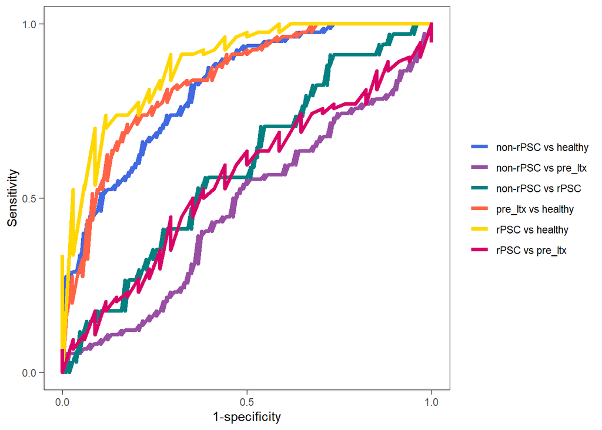

```r
roc_ileum <- roc_curve_all(roc_curve_data_list)
roc_ileum
```

### 4.1.3 Linear model

**PSC groups**

```r
results_model <- pairwise.lm(
  formula = "dys_filtered_genus ~ Group * Country",
  factors=metadata_ileum$Group,
  data=metadata_ileum)

knitr::kable(results_model[[1]][,c("Estimate", "p.adj","sig")],
             digits=3,caption="Results of linear modeling")
```

Results of linear modeling

|  | Estimate | p.adj | sig |
| --- | --- | --- | --- |
| healthy vs Groupnon-rPSC | 17.097 | 0.000 | *** |
| healthy , non-rPSC - CZ vs NO | -0.803 | 0.781 |  |
| healthy vs Groupnon-rPSC:CountryNO | -1.684 | 0.781 |  |
| healthy vs GrouprPSC | 22.812 | 0.000 | *** |
| healthy , rPSC - CZ vs NO | -0.803 | 0.781 |  |
| healthy vs GrouprPSC:CountryNO | -4.288 | 0.652 |  |
| healthy vs Grouppre_ltx | 25.244 | 0.000 | *** |
| healthy , pre_ltx - CZ vs NO | -0.803 | 0.781 |  |
| healthy vs Grouppre_ltx:CountryNO | -9.217 | 0.080 |  |
| non-rPSC vs GrouprPSC | 5.715 | 0.191 |  |
| non-rPSC , rPSC - CZ vs NO | -2.488 | 0.705 |  |
| non-rPSC vs GrouprPSC:CountryNO | -2.603 | 0.781 |  |
| pre_ltx vs Groupnon-rPSC | -8.148 | 0.056 |  |
| pre_ltx , non-rPSC - CZ vs NO | -10.021 | 0.033 | * |
| pre_ltx vs Groupnon-rPSC:CountryNO | 7.533 | 0.259 |  |
| pre_ltx vs GrouprPSC | -2.433 | 0.781 |  |
| pre_ltx , rPSC - CZ vs NO | -10.021 | 0.039 | * |
| pre_ltx vs GrouprPSC:CountryNO | 4.930 | 0.737 |  |

**IBD**

```r
results_model <- pairwise.lm(
  formula = "dys_filtered_genus ~ Group * Country",
  factors=metadata_ileum_for_plot$Group,
  data=metadata_ileum_for_plot)

knitr::kable(results_model[[1]],
             digits=3,caption="Results of linear modeling")
```

Results of linear modeling

|  | Estimate | Std. Error | t value | Pr(>\|t\|) |
| --- | --- | --- | --- | --- |
| no_ibd vs Groupibd | 4.144 | 4.022 | 1.030 | 0.304 |
| no_ibd , ibd - CZ vs NO | -7.866 | 5.111 | -1.539 | 0.125 |
| no_ibd vs Groupibd:CountryNO | 4.921 | 5.603 | 0.878 | 0.381 |

## 4.2 Colon

### 4.2.1 Boxplots

#### 4.2.1.1 PSC_groups

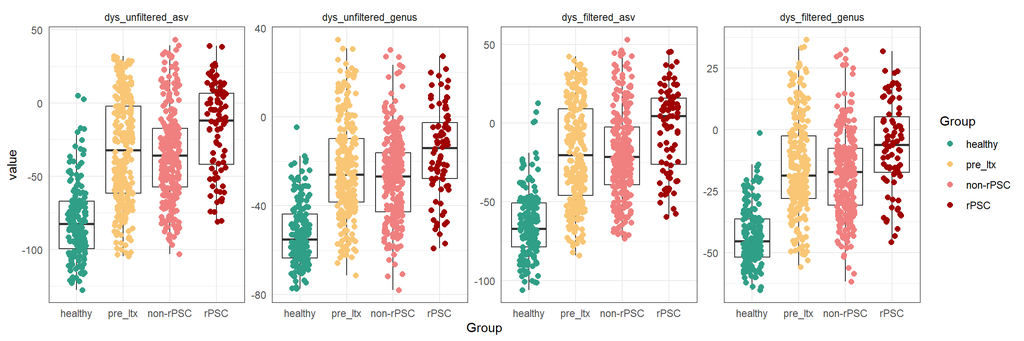

```r
colon_metadata_melted <- melt(metadata_colon %>%
                                dplyr::select("Group",
                                              "dys_unfiltered_asv",
                                              "dys_unfiltered_genus",
                                              "dys_filtered_asv",
                                              "dys_filtered_genus"))
p_col <- ggplot(colon_metadata_melted) +
  geom_boxplot(aes(x=Group, y=value),outliers = FALSE) +
  geom_jitter(width = 0.2,height = 0,
              aes(x=Group, y=value, color=Group),
              size=2) +
  facet_wrap(~variable, ncol = 4,scales = "free") +
  theme_minimal() +
 theme(panel.border = element_rect(color = "black", fill = NA, size = 0)) +
  scale_fill_manual(values=c("#309f87","#f9c675","#F08080","#A00000")) +
  scale_color_manual(values=c("#309f87","#f9c675","#F08080","#A00000"))

p_col
```

**FILTERED GENUS**

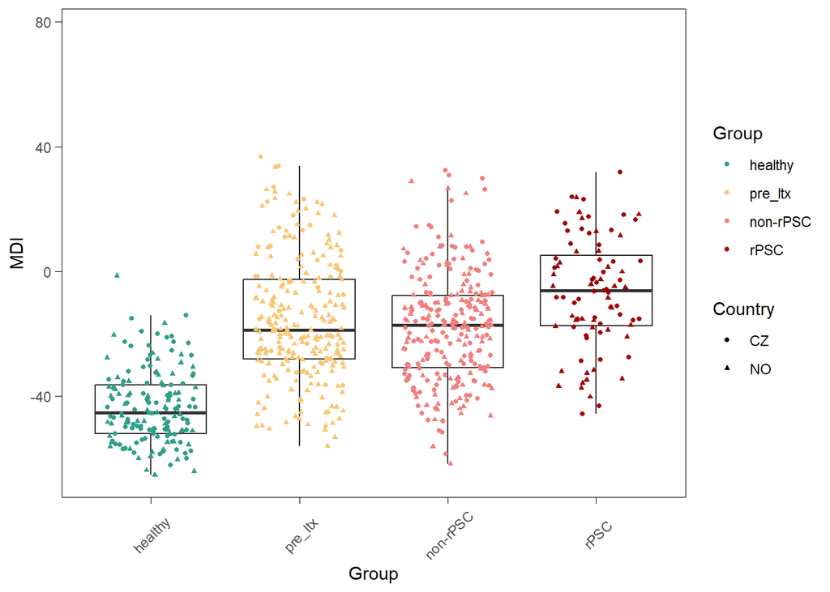

```r
dys_limit <- max(metadata_colon$dys_filtered_genus,na.rm = TRUE) + 1.1*max(metadata_colon$dys_filtered_genus,na.rm = TRUE)
dys_min_limit <-  min(metadata_colon$dys_filtered_genus)

p_col_dys_genus <- ggplot(metadata_colon %>%
                            mutate(`MDI`=dys_filtered_genus)) +
  geom_boxplot(aes(x=Group, y=`MDI`),outliers = FALSE) +
  geom_jitter(width = 0.3,height = 0,
              aes(x=Group, y=`MDI`, color=Group,shape=Country),
              size=1) +
  theme_minimal() +
    theme(panel.border = element_rect(color = "black", fill = NA, size = 0),
          axis.ticks.x = element_line(size=0.3,color = "black"),
          axis.ticks.y = element_line(size=0.3,color="black"),
          axis.ticks.length = unit(4,"pt"),
          panel.grid = element_blank()) +
  ylim(dys_min_limit,dys_limit) +
  scale_fill_manual(values=c("#309f87","#f9c675","#F08080","#A00000")) +
  scale_color_manual(values=c("#309f87","#f9c675","#F08080","#A00000")) +
  theme(axis.text.x = element_text(angle = 45,vjust = 0.5))

p_col_dys_genus
```

#### 4.2.1.2 IBD

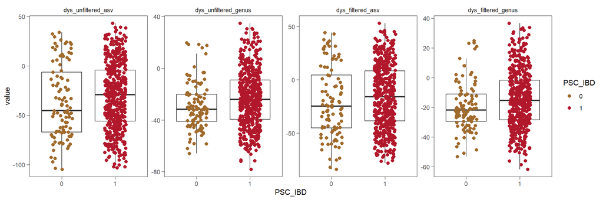

```r
metadata_colon_melted <- melt(metadata_colon %>%
                                dplyr::filter(PSC_IBD %in% c(0,1)) %>%
                                dplyr::select("PSC_IBD",
                                              "dys_unfiltered_asv",
                                              "dys_unfiltered_genus",
                                              "dys_filtered_asv",
                                              "dys_filtered_genus"))
p_col <- ggplot(metadata_colon_melted) +
  geom_boxplot(aes(x=PSC_IBD, y=value),outliers = FALSE) +
  geom_jitter(width = 0.2,height = 0,aes(x=PSC_IBD, y=value, color=PSC_IBD),
              size=2) +
  facet_wrap(~variable, ncol = 4,scales = "free") +
  theme_minimal() +
    theme(panel.border = element_rect(color = "black", fill = NA, size = 0),
          axis.ticks.x = element_line(size=0.3,color = "black"),
          axis.ticks.y = element_line(size=0.3,color="black"),
          axis.ticks.length = unit(4,"pt"),
          panel.grid = element_blank()) +
  scale_fill_manual(values=c("#A06A2C", "#B2182B")) +
  scale_color_manual(values=c("#A06A2C", "#B2182B"))

p_col
```

**FILTERED GENUS**

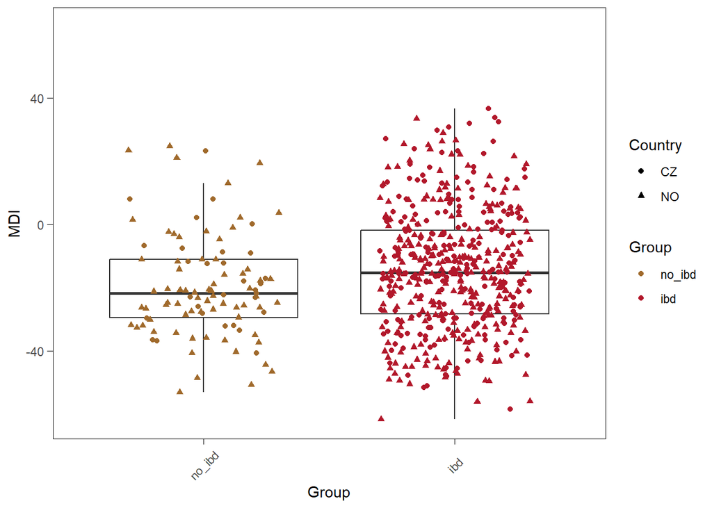

```r
metadata_colon_for_plot <- metadata_colon %>%
                                dplyr::filter(PSC_IBD %in% c(0,1)) %>%
  mutate(Group=case_when(PSC_IBD == 1 ~ "ibd",
                       PSC_IBD == 0 ~ "no_ibd"))

metadata_colon_for_plot$Group <- factor(metadata_colon_for_plot$Group,levels = c("no_ibd","ibd"))

dys_limit <- max(metadata_colon_for_plot$dys_filtered_genus,na.rm = TRUE) + 0.7*max(metadata_colon_for_plot$dys_filtered_genus,na.rm = TRUE)
dys_min_limit <-  min(metadata_colon_for_plot$dys_filtered_genus)

p_col_dys_genus_ibd <- ggplot(metadata_colon_for_plot %>%
                           mutate(`MDI`=dys_filtered_genus)) +
  geom_boxplot(aes(x=Group, y=`MDI`),
               outliers = FALSE) +
  geom_jitter(width = 0.3,height = 0,
              aes(x=Group, y=`MDI`, color=Group,shape=Country),
              size=1.5) +
  theme_minimal() +
    theme(panel.border = element_rect(color = "black", fill = NA, size = 0),
          axis.ticks.x = element_line(size=0.3,color = "black"),
          axis.ticks.y = element_line(size=0.3,color="black"),
          axis.ticks.length = unit(4,"pt"),
          panel.grid = element_blank()) +
  ylim(dys_min_limit,dys_limit) +
  scale_fill_manual(values=c("#A06A2C", "#B2182B")) +
  scale_color_manual(values=c("#A06A2C", "#B2182B")) +
  theme(axis.text.x = element_text(angle = 45,vjust = 0.5))

p_col_dys_genus_ibd
```

### 4.2.2 ROCs

```r
metadata_colon_auc <- metadata_colon %>%
  group_by(PatientID) %>%
  distinct(PatientID, .keep_all = TRUE) %>%
  as.data.frame()

comparisons <- combn(unique(metadata_colon_auc$Group), 2, simplify = TRUE)
comparisons <- comparisons[,c(3,2,1,6,5,4)]

auc_df <- data.frame(Comparison=rep(NA,ncol(comparisons)),
                     AUC=rep(NA,ncol(comparisons)))

roc_curve_list <- list()
roc_curve_data_list <- list()

for (i in 1:ncol(comparisons)){
  name <- paste0(comparisons[1,i]," vs ", comparisons[2,i])
  metadata_sub <- subset(metadata_colon_auc,metadata_colon_auc$Group %in% comparisons[,i])
  metadata_sub$Group <- factor(metadata_sub$Group,
                               levels=c(comparisons[1,i],comparisons[2,i]))
  roc_curve_data <- roc(metadata_sub$Group, metadata_sub$dys_unfiltered_genus)
  auc_value <- auc(roc_curve_data)  # Compute AUC
  auc_df[i,] <- c(name,auc_value)
  roc_curve_list[[name]] <- ggroc(roc_curve_data) +
    theme_minimal() +
    theme(legend.position = "none") +
    ggtitle(paste0(name,' (AUC = ', round(auc_value,2),")")) +
    theme(plot.title = element_text(size = 7))
  roc_curve_data_list[[name]] <- roc_curve_data
}
auc_df
```

```
           Comparison               AUC
1 non-rPSC vs healthy 0.849832952347459
2 non-rPSC vs pre_ltx 0.560759106213652
3    non-rPSC vs rPSC 0.675293605915615
4  pre_ltx vs healthy 0.877167060677699
5     rPSC vs healthy 0.924132138857783
6     rPSC vs pre_ltx   0.6135477582846
```

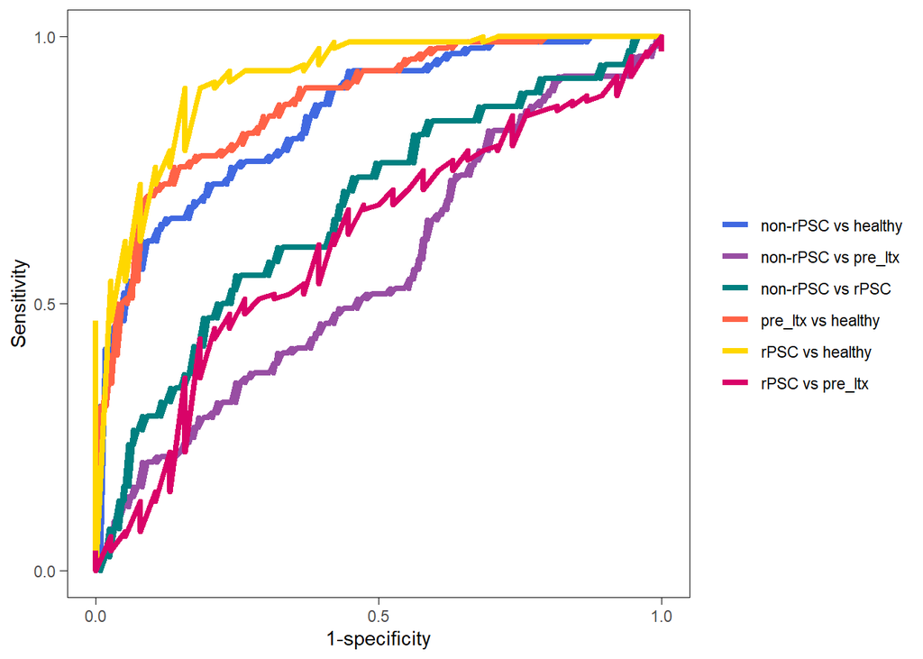

```r
roc_colon <- roc_curve_all(roc_curve_data_list)
roc_colon
```

### 4.2.3 Linear model

```r
results_model <- pairwise.lmer(
  formula = "dys_filtered_genus ~ Group * Country + (1|PatientID)",
  factors=metadata_colon$Group,
  data=metadata_colon)

knitr::kable(results_model[[1]][,c("Estimate", "p.adj","sig")],
             digits=3,caption="Results of linear mixed-effect modeling")
```

Results of linear mixed-effect modeling

|  | Estimate | p.adj | sig |
| --- | --- | --- | --- |
| healthy vs Groupnon-rPSC | 25.818 | 0.000 | *** |
| healthy vs non-rPSC - CZ vs NO | -0.432 | 0.955 |  |
| healthy vs Groupnon-rPSC:CountryNO | -0.240 | 0.956 |  |
| healthy vs GrouprPSC | 40.128 | 0.000 | *** |
| healthy vs rPSC - CZ vs NO | -0.426 | 0.955 |  |
| healthy vs GrouprPSC:CountryNO | -6.892 | 0.362 |  |
| healthy vs Grouppre_ltx | 37.540 | 0.000 | *** |
| healthy vs pre_ltx - CZ vs NO | -0.420 | 0.955 |  |
| healthy vs Grouppre_ltx:CountryNO | -11.185 | 0.058 |  |
| non-rPSC vs GrouprPSC | 14.312 | 0.002 | ** |
| non-rPSC vs rPSC - CZ vs NO | -0.667 | 0.955 |  |
| non-rPSC vs GrouprPSC:CountryNO | -6.662 | 0.528 |  |
| pre_ltx vs Groupnon-rPSC | -11.706 | 0.016 | * |
| pre_ltx vs non-rPSC - CZ vs NO | -11.601 | 0.016 | * |
| pre_ltx vs Groupnon-rPSC:CountryNO | 10.936 | 0.089 |  |
| pre_ltx vs GrouprPSC | 2.640 | 0.853 |  |
| pre_ltx vs rPSC - CZ vs NO | -11.582 | 0.019 | * |
| pre_ltx vs GrouprPSC:CountryNO | 4.228 | 0.853 |  |

**IBD**

```r
results_model <- pairwise.lmer(
  formula = "dys_filtered_genus ~ Group * Country + (1|PatientID)",
  factors=metadata_colon_for_plot$Group,
  data=metadata_colon_for_plot)

knitr::kable(results_model[[1]],
             digits=3,caption="Results of linear modeling")
```

Results of linear modeling

|  | Estimate | Std..Error | df | t.value | Pr…t.. | p.adj | sig |
| --- | --- | --- | --- | --- | --- | --- | --- |
| no_ibd vs Groupibd | 5.771 | 4.110 | 437.349 | 1.404 | 0.161 | 0.161 |  |
| no_ibd vs ibd - CZ vs NO | -3.164 | 5.250 | 331.780 | -0.603 | 0.547 | 0.547 |  |
| no_ibd vs Groupibd:CountryNO | -0.886 | 5.687 | 340.946 | -0.156 | 0.876 | 0.876 |  |

```r
library(pwr)
# Fit  linear model
lmm <- lmer(dys_filtered_genus ~ Group * Country + (1|PatientID), metadata_colon_for_plot)

# Extract the fixed effect estimate for X
beta <- fixef(lmm)["Groupibd"]

# Extract residual standard deviation
sd_resid <- sigma(lmm)

# Compute Cohen's d
cohen_d <- beta / sd_resid
cohen_d
```

```
Groupibd
1.001531
```

```r
# Define parameters
u <- 2
v <- length(metadata_ileum_for_plot$SampleID) - u - 1  # Residual degrees of freedom (Total sample size - predictors - 1)
f2 <- 1 # Cohen’s f² effect size (0.02 = small, 0.15 = medium, 0.35 = large)
alpha <- 0.05  # Significance level
power <- pwr.f2.test(u = u, v = v, f2 = f2, sig.level = alpha)
power
```

```
     Multiple regression power calculation

              u = 2
              v = 211
             f2 = 1
      sig.level = 0.05
          power = 1
```

## 4.3 Saving results

# 5 Alpha diversity

```r
# needed variables
alpha_div_plots <- list()
alpha_boxplots <- list()
corrs <- list()
```

## 5.1 Terminal ileum

```r
ileum_metadata_alpha_final <- metadata_ileum %>%
  dplyr::select("SampleID", "PatientID","Group","Country",
                "Observe","Shannon","Simpson","Pielou",
                "dys_filtered_asv", "dys_filtered_genus")
```

```r
variables <- c("Observe","Shannon","Simpson","Pielou")

for (clinical_variable in variables){

  # ILEUM
  # boxplot
  p <- clinical_boxplot(ileum_metadata_alpha_final,
                      variable=clinical_variable)

  alpha_boxplots[[paste0("ileum_",clinical_variable)]] <- p

  # correlation
  ## ASV
  level="ASV"
  corr <- clinical_correlation(
    ileum_metadata_alpha_final,
    clinical_variable,
    level)

  corrs[[paste0("ileum_asv_",clinical_variable)]] <- corr

  p <- clinical_scatter(corr,
                        ileum_metadata_alpha_final,
                        clinical_variable,
                        level)

  alpha_div_plots[[paste0("ileum_asv_",clinical_variable)]] <- p

  ## Genus
  level="genus"
  corr <- clinical_correlation(ileum_metadata_alpha_final,
                               clinical_variable,
                               level)
  corrs[[paste0("ileum_genus_",clinical_variable)]] <- corr

  p <- clinical_scatter(corr,
                        ileum_metadata_alpha_final,
                        clinical_variable,
                        level)

  alpha_div_plots[[paste0("ileum_genus_",clinical_variable)]] <- p
}
```

### 5.1.1 Boxplot

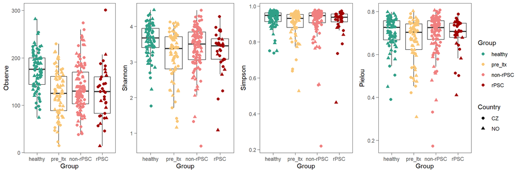

```r
alpha_boxplots_ileum <- ggarrange(
  plotlist = alpha_boxplots[grepl("ileum",names(alpha_boxplots))],
  ncol = 4,
  common.legend = TRUE,
  legend = "right")

alpha_boxplots_ileum
```

## 5.2 Colon

```r
colon_metadata_alpha_final <- metadata_colon %>%
  dplyr::select("SampleID", "PatientID", "Group","Country",
                "Observe","Shannon","Simpson","Pielou",
                "dys_filtered_asv","dys_filtered_genus")
```

```r
variables <- c("Observe","Shannon","Simpson","Pielou")

for (clinical_variable in variables){

  # COLUMN
  p <- clinical_boxplot(colon_metadata_alpha_final,
                        variable=clinical_variable)

  alpha_boxplots[[paste0("colon_",clinical_variable)]] <- p

  # correlation
  ## ASV
  level="ASV"
  corr <- clinical_correlation(colon_metadata_alpha_final,
                               clinical_variable,
                               level,
                               segment="colon")

  corrs[[paste0("colon_asv_",clinical_variable)]] <- corr

  p <- clinical_scatter(corr,
                        colon_metadata_alpha_final,
                        clinical_variable,
                        level)

  alpha_div_plots[[paste0("colon_asv_",clinical_variable)]] <- p

  ## Genus
  level="genus"
  corr <- clinical_correlation(colon_metadata_alpha_final,
                               clinical_variable,
                               level,
                               segment="colon")

  corrs[[paste0("colon_genus_",clinical_variable)]] <- corr

  p <- clinical_scatter(corr,
                        colon_metadata_alpha_final,
                        clinical_variable,
                        level)

  alpha_div_plots[[paste0("colon_genus_",clinical_variable)]] <- p
}
```

### 5.2.1 Boxplot

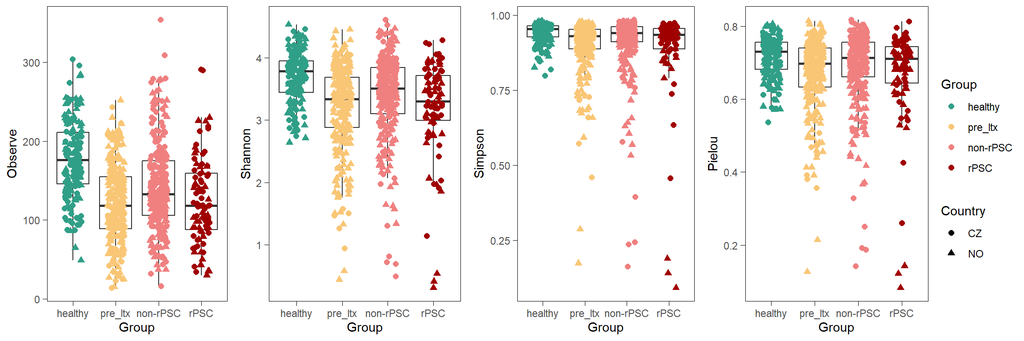

```r
alpha_boxplots_colon <- ggarrange(
  plotlist = alpha_boxplots[grepl("colon",names(alpha_boxplots))],
  ncol = 4,
  common.legend = TRUE,
  legend = "right")

alpha_boxplots_colon
```

## 5.3 Scatterplots

**ASV**

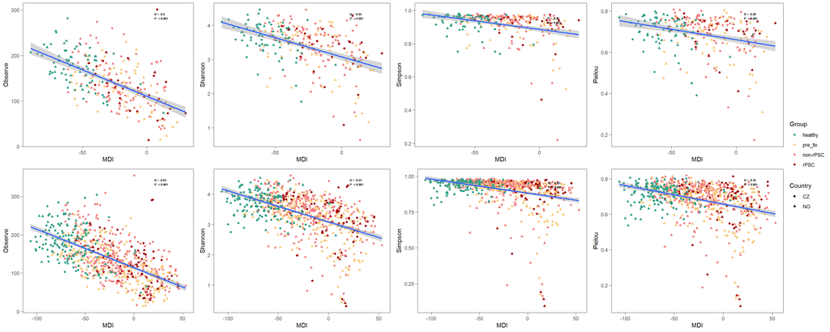

```r
alpha_dys_asv <- ggarrange(
  plotlist = alpha_div_plots[grepl("asv",names(alpha_div_plots))],
  ncol=4,
  nrow=2,
  common.legend = TRUE,
  legend="right")
alpha_dys_asv
```

**Genus**

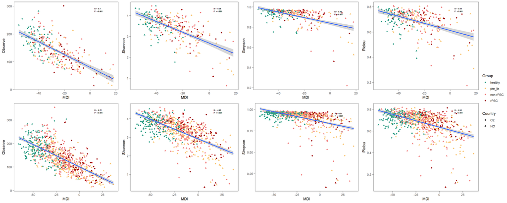

```r
alpha_dys_genus <- ggarrange(
  plotlist = alpha_div_plots[grepl("genus",names(alpha_div_plots))],
  ncol=4,
  nrow=2,
  common.legend = TRUE,
  legend="right")
alpha_dys_genus
```

## 5.4 Linear models

### 5.4.1 Richness

**Ileum**

```r
results_model <- pairwise.lm(formula = "Observe ~ Group * Country",
                                     factors=metadata_ileum$Group,
                                     data=metadata_ileum)

knitr::kable(results_model[[1]][,c("Estimate", "p.adj","sig")],
             digits=3,caption="Results of linear modeling")
```

Results of linear modeling

|  | Estimate | p.adj | sig |
| --- | --- | --- | --- |
| healthy vs Groupnon-rPSC | -25.110 | 0.045 | * |
| healthy , non-rPSC - CZ vs NO | 11.219 | 0.346 |  |
| healthy vs Groupnon-rPSC:CountryNO | -31.594 | 0.112 |  |
| healthy vs GrouprPSC | -37.475 | 0.025 | * |
| healthy , rPSC - CZ vs NO | 11.219 | 0.346 |  |
| healthy vs GrouprPSC:CountryNO | -22.969 | 0.346 |  |
| healthy vs Grouppre_ltx | -53.642 | 0.000 | *** |
| healthy , pre_ltx - CZ vs NO | 11.219 | 0.346 |  |
| healthy vs Grouppre_ltx:CountryNO | 6.313 | 0.710 |  |
| non-rPSC vs GrouprPSC | -12.365 | 0.346 |  |
| non-rPSC , rPSC - CZ vs NO | -20.375 | 0.200 |  |
| non-rPSC vs GrouprPSC:CountryNO | 8.625 | 0.710 |  |
| pre_ltx vs Groupnon-rPSC | 28.532 | 0.061 |  |
| pre_ltx , non-rPSC - CZ vs NO | 17.533 | 0.346 |  |
| pre_ltx vs Groupnon-rPSC:CountryNO | -37.907 | 0.081 |  |
| pre_ltx vs GrouprPSC | 16.167 | 0.346 |  |
| pre_ltx , rPSC - CZ vs NO | 17.533 | 0.346 |  |
| pre_ltx vs GrouprPSC:CountryNO | -29.283 | 0.346 |  |

**Colon**

```r
results_model <- pairwise.lmer(
  formula = "Observe ~ Group * Country + (1|Patient)",
  factors=metadata_colon$Group,
  data=metadata_colon %>% mutate(Patient=PatientID))

knitr::kable(results_model[[1]][,c("Estimate", "p.adj","sig")],
             digits=3,caption="Results of linear modeling")
```

Results of linear modeling

|  | Estimate | p.adj | sig |
| --- | --- | --- | --- |
| healthy vs Groupnon-rPSC | -23.300 | 0.045 | * |
| healthy vs non-rPSC - CZ vs NO | 14.430 | 0.284 |  |
| healthy vs Groupnon-rPSC:CountryNO | -32.063 | 0.113 |  |
| healthy vs GrouprPSC | -40.512 | 0.009 | ** |
| healthy vs rPSC - CZ vs NO | 14.241 | 0.284 |  |
| healthy vs GrouprPSC:CountryNO | -28.963 | 0.284 |  |
| healthy vs Grouppre_ltx | -56.230 | 0.000 | *** |
| healthy vs pre_ltx - CZ vs NO | 14.193 | 0.284 |  |
| healthy vs Grouppre_ltx:CountryNO | -7.489 | 0.659 |  |
| non-rPSC vs GrouprPSC | -17.130 | 0.284 |  |
| non-rPSC vs rPSC - CZ vs NO | -17.626 | 0.284 |  |
| non-rPSC vs GrouprPSC:CountryNO | 2.894 | 0.893 |  |
| pre_ltx vs Groupnon-rPSC | 32.865 | 0.040 | * |
| pre_ltx vs non-rPSC - CZ vs NO | 6.762 | 0.647 |  |
| pre_ltx vs Groupnon-rPSC:CountryNO | -24.384 | 0.284 |  |
| pre_ltx vs GrouprPSC | 15.660 | 0.396 |  |
| pre_ltx vs rPSC - CZ vs NO | 6.652 | 0.647 |  |
| pre_ltx vs GrouprPSC:CountryNO | -21.362 | 0.405 |  |

### 5.4.2 Shannon

**Ileum**

```r
results_model <- pairwise.lm(formula = "Shannon ~ Group * Country",
                                     factors=metadata_ileum$Group,
                                     data=metadata_ileum)

knitr::kable(results_model[[1]][,c("Estimate", "p.adj","sig")],
             digits=3,caption="Results of linear modeling")
```

Results of linear modeling

|  | Estimate | p.adj | sig |
| --- | --- | --- | --- |
| healthy vs Groupnon-rPSC | -0.109 | 0.576 |  |
| healthy , non-rPSC - CZ vs NO | 0.007 | 0.994 |  |
| healthy vs Groupnon-rPSC:CountryNO | -0.356 | 0.205 |  |
| healthy vs GrouprPSC | -0.212 | 0.289 |  |
| healthy , rPSC - CZ vs NO | 0.007 | 0.994 |  |
| healthy vs GrouprPSC:CountryNO | -0.358 | 0.289 |  |
| healthy vs Grouppre_ltx | -0.505 | 0.034 | * |
| healthy , pre_ltx - CZ vs NO | 0.007 | 0.994 |  |
| healthy vs Grouppre_ltx:CountryNO | 0.144 | 0.634 |  |
| non-rPSC vs GrouprPSC | -0.103 | 0.634 |  |
| non-rPSC , rPSC - CZ vs NO | -0.350 | 0.080 |  |
| non-rPSC vs GrouprPSC:CountryNO | -0.002 | 0.994 |  |
| pre_ltx vs Groupnon-rPSC | 0.396 | 0.080 |  |
| pre_ltx , non-rPSC - CZ vs NO | 0.150 | 0.576 |  |
| pre_ltx vs Groupnon-rPSC:CountryNO | -0.500 | 0.115 |  |
| pre_ltx vs GrouprPSC | 0.293 | 0.289 |  |
| pre_ltx , rPSC - CZ vs NO | 0.150 | 0.576 |  |
| pre_ltx vs GrouprPSC:CountryNO | -0.502 | 0.289 |  |

**Colon**

```r
results_model <- pairwise.lmer(
  formula = "Shannon ~ Group * Country + (1|Patient)",
  factors=metadata_colon$Group,
  data=metadata_colon %>% mutate(Patient=PatientID))

knitr::kable(results_model[[1]][,c("Estimate", "p.adj","sig")],
             digits=3,caption="Results of linear modeling")
```

Results of linear modeling

|  | Estimate | p.adj | sig |
| --- | --- | --- | --- |
| healthy vs Groupnon-rPSC | -0.184 | 0.182 |  |
| healthy vs non-rPSC - CZ vs NO | 0.016 | 0.961 |  |
| healthy vs Groupnon-rPSC:CountryNO | -0.378 | 0.091 |  |
| healthy vs GrouprPSC | -0.334 | 0.061 |  |
| healthy vs rPSC - CZ vs NO | 0.014 | 0.961 |  |
| healthy vs GrouprPSC:CountryNO | -0.361 | 0.207 |  |
| healthy vs Grouppre_ltx | -0.585 | 0.001 | ** |
| healthy vs pre_ltx - CZ vs NO | 0.015 | 0.961 |  |
| healthy vs Grouppre_ltx:CountryNO | 0.081 | 0.852 |  |
| non-rPSC vs GrouprPSC | -0.148 | 0.591 |  |
| non-rPSC vs rPSC - CZ vs NO | -0.360 | 0.061 |  |
| non-rPSC vs GrouprPSC:CountryNO | 0.013 | 0.962 |  |
| pre_ltx vs Groupnon-rPSC | 0.399 | 0.061 |  |
| pre_ltx vs non-rPSC - CZ vs NO | 0.095 | 0.790 |  |
| pre_ltx vs Groupnon-rPSC:CountryNO | -0.455 | 0.095 |  |
| pre_ltx vs GrouprPSC | 0.251 | 0.407 |  |
| pre_ltx vs rPSC - CZ vs NO | 0.095 | 0.790 |  |
| pre_ltx vs GrouprPSC:CountryNO | -0.442 | 0.283 |  |

# 6 FIGURE 5

```r
terminal_ileum_list <- list(
  ileum_genus_mdi_boxplot=p_il_dys_genus +
    theme(legend.position = "none") +
    ggtitle("Terminal ileum") +
    theme(plot.title = element_text(hjust=0.5,face = "bold",size = 15)),
  ileum_genus_observe=                          alpha_div_plots[grepl("ileum_genus",names(alpha_div_plots))][[2]] +
    theme(legend.position = "none")#+ ylab("Richness")
  )

p_terminal_ileum <- ggarrange(
  plotlist = terminal_ileum_list,
  ncol=1,
  nrow=2,heights = c(1.2,0.8),labels = c("A","B"))
colon_list <- list(
  colon_genus_mdi_boxplot=p_col_dys_genus +
    theme(legend.position = "none") +
  ggtitle("Colon") +
    theme(plot.title = element_text(hjust=0.5,face = "bold",size = 15)),
  colon_genus_observe=                          alpha_div_plots[grepl("colon_genus",names(alpha_div_plots))][[2]] +
    theme(legend.position = "none") #+ ylab("Shannon")
  )

p_colon <- ggarrange(
  plotlist = colon_list,
  ncol=1,
  nrow=2,heights = c(1.2,0.8))
p <- ggarrange(p_terminal_ileum,p_colon,ncol=2,common.legend = TRUE,
  legend="right")

p <- ggarrange(p,ggplot() + theme_minimal(),ncol=2,
                                widths = c(1,0.15))
```

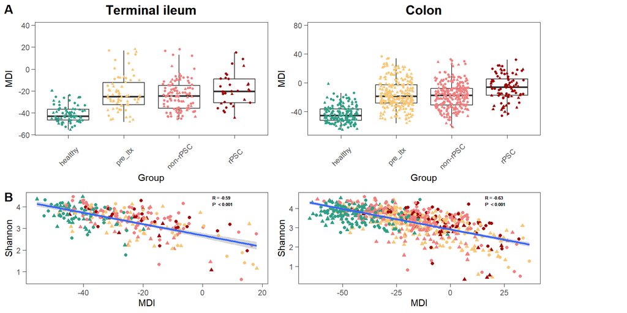

```r
p
```

# 7 Clinical variables comparison

## 7.1 PSC groups

```r
variables <- c("log_Bilirubin","Albumin","log_ALP","Platelets","log_Calprotectin","AOM","log_APRI","INR","log_FIB4","log_Creatinine","log_ALT","log_AST","log_GGT","Nancy_max","eMAYO","MAYO_dai")
```

```r
metadata_for_boxplots_psc <- metadata_for_boxplots %>%
  dplyr::mutate(Group = case_when(
      Group == "pre_ltx" ~ "pre_LTx",
      Group == "non-rPSC" ~ "post_LTx",
      Group == "rPSC" ~ "post_LTx",
      TRUE ~ Group  # Keep other values as is
    )) %>%
  dplyr::select(-PSC_IBD)

metadata_for_boxplots_psc$Group <- factor(
    metadata_for_boxplots_psc$Group,levels=c("healthy","pre_LTx","post_LTx"))

test_df <- data.frame(`Variable`=NA,
                      `healthy_vs_pre_LTx`=NA,
                      `healthy_vs_post_LTx`=NA,
                      `pre_LTx_vs_post_LTx`=NA,check.names = FALSE)

boxplots_plots <- list()

i <- 1

for (clinical_variable in variables){
  if (grepl("log_",clinical_variable)) {
   metadata_for_boxplots_psc[,clinical_variable] <- log(
     as.numeric(metadata_for_boxplots_psc[,gsub("log_","",clinical_variable)])
     )
  }

  df <- metadata_for_boxplots_psc %>% dplyr::select("Group",clinical_variable)
  df <- df %>% drop_na()

  p <- clinical_boxplot(metadata_for_boxplots_psc,variable=clinical_variable)

  boxplots_plots[[clinical_variable]] <- p

  p_test <- pairwise.wilcox.test(
    df[,clinical_variable],
    df$Group,
    p.adjust.method = "BH")$p.value

  if (all(dim(p_test)>0)){
    if (all(colnames(p_test) == c("healthy","pre_LTx")) &
      all(rownames(p_test) == c("pre_LTx","post_LTx"))){

      test_df[i,] <- c(clinical_variable,
                     round(p_test[1,1],3),
                     round(p_test[2,1],3),
                     round(p_test[2,2],3))

  } else if (all(colnames(p_test) == c("pre_LTx")) &
      all(rownames(p_test) == c("post_LTx"))) {

      test_df[i,] <- c(clinical_variable,
                       NA,NA,
                       round(p_test[1,1],3))

    } else{ cat(clinical_variable)}
  } else{ cat(clinical_variable)}

  i <- i +1

}

test_df[,-1] <- as.numeric(as.matrix(test_df[,-1]))
significance_df <- test_df[,-1]
significance_df[test_df[,-1] <= 0.05] <-'*'
significance_df[test_df[,-1] <= 0.01] <-'**'
significance_df[test_df[,-1] <= 0.001] <-'***'
significance_df$Variable <- test_df$Variable
write.xlsx(significance_df,"../results/clinical_significance.xlsx")

significance_df %<>% column_to_rownames("Variable")
```

### 7.1.1 Test

```r
knitr::kable(significance_df,
             digits=3,caption="Pairwise wilcox test of clinical variables")
```

Pairwise wilcox test of clinical variables

|  | healthy_vs_pre_LTx | healthy_vs_post_LTx | pre_LTx_vs_post_LTx |
| --- | --- | --- | --- |
| log_Bilirubin | ** | 0.798 | *** |
| Albumin | *** | *** | *** |
| log_ALP | *** | * | *** |
| Platelets | 0.318 | *** | *** |
| log_Calprotectin | NA | NA | * |
| AOM | NA | NA | 0.726 |
| log_APRI | *** | *** | *** |
| INR | 0.968 | 0.968 | 0.638 |
| log_FIB4 | ** | *** | 0.873 |
| log_Creatinine | *** | ** | *** |
| log_ALT | *** | 0.855 | *** |
| log_AST | *** | 0.384 | *** |
| log_GGT | *** | 0.197 | *** |
| Nancy_max | NA | NA | 0.785 |
| eMAYO | NA | NA | 0.515 |
| MAYO_dai | NA | NA | 0.188 |

### 7.1.2 Boxplots

```r
for (i in 1:length(boxplots_plots)){
  name <- names(boxplots_plots)[i]
  pl <- boxplots_plots[[i]]
  pl <- pl + ggtitle(name)
  boxplots_plots[[i]] <- pl
}
bx <- ggarrange(plotlist = boxplots_plots, ncol = 4,nrow=4)
```

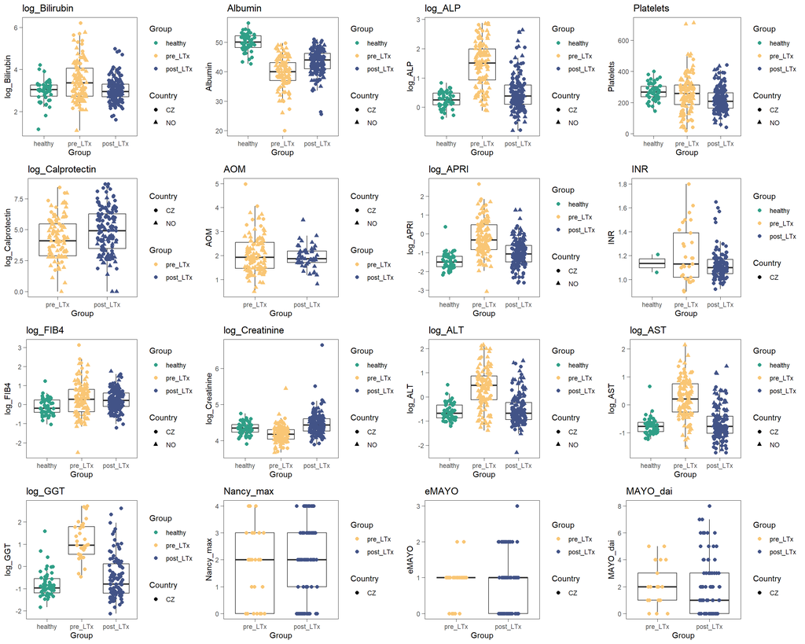

```r
bx
```

## 7.2 IBD

```r
variables <- c("log_Bilirubin","Albumin","log_ALP","Platelets","log_Calprotectin","AOM","log_APRI","INR","log_FIB4","log_Creatinine","log_ALT","log_AST","log_GGT","Nancy_max","eMAYO","MAYO_dai")
```

```r
test_df <- data.frame(`Variable`=NA,
                      `ibd_vs_noibd`=NA)

boxplots_plots <- list()
metadata_for_boxplots_ibd <- metadata_for_boxplots %>% dplyr::filter(PSC_IBD %in% c(0,1))

metadata_for_boxplots_ibd$Group
```

```
  [1] non-rPSC rPSC     non-rPSC non-rPSC non-rPSC rPSC     non-rPSC pre_ltx
  [9] pre_ltx  pre_ltx  pre_ltx  pre_ltx  pre_ltx  non-rPSC pre_ltx  pre_ltx
 [17] pre_ltx  non-rPSC pre_ltx  pre_ltx  rPSC     pre_ltx  non-rPSC non-rPSC
 [25] rPSC     pre_ltx  pre_ltx  pre_ltx  non-rPSC non-rPSC rPSC     pre_ltx
 [33] non-rPSC non-rPSC non-rPSC pre_ltx  non-rPSC pre_ltx  non-rPSC pre_ltx
 [41] pre_ltx  non-rPSC pre_ltx  rPSC     non-rPSC pre_ltx  pre_ltx  pre_ltx
 [49] pre_ltx  non-rPSC pre_ltx  pre_ltx  non-rPSC pre_ltx  pre_ltx  pre_ltx
 [57] non-rPSC pre_ltx  rPSC     pre_ltx  rPSC     non-rPSC pre_ltx  pre_ltx
 [65] non-rPSC non-rPSC pre_ltx  pre_ltx  non-rPSC pre_ltx  non-rPSC non-rPSC
 [73] pre_ltx  non-rPSC non-rPSC non-rPSC pre_ltx  pre_ltx  pre_ltx  non-rPSC
 [81] pre_ltx  pre_ltx  pre_ltx  pre_ltx  non-rPSC pre_ltx  pre_ltx  pre_ltx
 [89] non-rPSC pre_ltx  pre_ltx  pre_ltx  pre_ltx  non-rPSC rPSC     rPSC
 [97] pre_ltx  pre_ltx  pre_ltx  non-rPSC non-rPSC pre_ltx  pre_ltx  pre_ltx
[105] pre_ltx  pre_ltx  pre_ltx  non-rPSC pre_ltx  pre_ltx  pre_ltx  rPSC
[113] rPSC     pre_ltx  pre_ltx  pre_ltx  pre_ltx  pre_ltx  pre_ltx  pre_ltx
```

[output cut: 20 more lines]

```r
i <- 1

for (clinical_variable in variables){
  if (grepl("log_",clinical_variable)) {
   metadata_for_boxplots_ibd[,clinical_variable] <- log(
     as.numeric(metadata_for_boxplots_ibd[,gsub("log_","",clinical_variable)])
     )
  }

  df <- metadata_for_boxplots_ibd %>% dplyr::select("PSC_IBD",clinical_variable)

  df$PSC_IBD <- factor(df$PSC_IBD,levels=c("0","1"))
  df <- df %>% drop_na()

  p_test <- pairwise.wilcox.test(
    df[,clinical_variable],
    df$PSC_IBD,
    p.adjust.method = "BH")$p.value

  if (length(p_test)==0) test_df[i,] <- c(clinical_variable,NA)
  else if ((colnames(p_test)==0) & (rownames(p_test)==1)){
    test_df[i,] <- c(clinical_variable,
                     round(p_test[1,1],3))
  } else{
    cat(clinical_variable)
  }

  # boxplot
  p <- clinical_boxplot(metadata_for_boxplots_ibd,
                      variable=clinical_variable)

  boxplots_plots[[clinical_variable]] <- p

  i <- i +1

}

test_df[,-1] <- as.numeric(as.matrix(test_df[,-1]))
significance_df <- test_df[,-1]
significance_df[test_df[,-1] <= 0.05] <-'*'
significance_df[test_df[,-1] <= 0.01] <-'**'
significance_df[test_df[,-1] <= 0.001] <-'***'
significance_df %<>% as.data.frame()
significance_df$Variable <- test_df$Variable
colnames(significance_df) <- c("ibd_vs_noibd","Variable")

write.xlsx(significance_df,"../results/clinical_significance_ibd.xlsx")

significance_df %<>% column_to_rownames("Variable")
```

### 7.2.1 Test

```r
knitr::kable(significance_df,
             digits=3,caption="Pairwise wilcox test of clinical variables")
```

Pairwise wilcox test of clinical variables

|  | ibd_vs_noibd |
| --- | --- |
| log_Bilirubin | 0.154 |
| Albumin | 0.396 |
| log_ALP | 0.968 |
| Platelets | 0.412 |
| log_Calprotectin | *** |
| AOM | * |
| log_APRI | 0.087 |
| INR | 0.298 |
| log_FIB4 | ** |
| log_Creatinine | ** |
| log_ALT | 0.159 |
| log_AST | 0.201 |
| log_GGT | 0.592 |
| Nancy_max | NA |
| eMAYO | NA |
| MAYO_dai | NA |

### 7.2.2 Boxplots

```r
for (i in 1:length(boxplots_plots)){
  name <- names(boxplots_plots)[i]
  pl <- boxplots_plots[[i]]
  pl <- pl + ggtitle(name)
  boxplots_plots[[i]] <- pl
}
bx <- ggarrange(plotlist = boxplots_plots, ncol = 4,nrow=4)
```

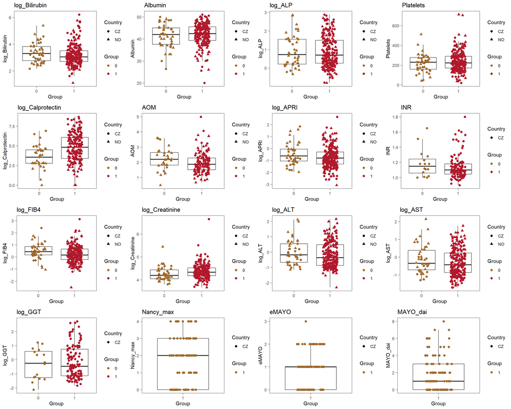

```r
bx
```

# 8 MDI and clinical variables

```r
variables <- c("ALP","log_ALP",
               "GGT","log_GGT",
               "ALT","log_ALT",
               "AST","log_AST",
               "Bilirubin","log_Bilirubin",
               "INR","log_INR",
               "Albumin",
               "Platelets",
               "Creatinine","log_Creatinine",
               "FIB4","log_FIB4",
               "APRI","log_APRI",
               "MAYO_PSC",
               "AOM",
               "Calprotectin","log_Calprotectin",
               "Nancy_max","eMAYO","MAYO_dai")
```

```r
corrs <- list()
clinical_plots <- list()

for (clinical_variable in variables){

  if (grepl("log_",clinical_variable)) {
   metadata_for_boxplots[,clinical_variable] <- log(as.numeric(metadata_for_boxplots[,gsub("log_","",clinical_variable)]))

   metadata_ileum[,clinical_variable] <- log(as.numeric(metadata_ileum[,gsub("log_","",clinical_variable)]))
   metadata_colon[,clinical_variable] <- log(as.numeric(metadata_colon[,gsub("log_","",clinical_variable)]))
  }

  # ILEUM
  # correlation

  ## ASV
  level="ASV"
  corr <- clinical_correlation(metadata_ileum,
                               clinical_variable,
                               level)

  corrs[[paste0("ileum_asv_",clinical_variable)]] <- corr

  p <- clinical_scatter(corr,
                        metadata_ileum,
                        clinical_variable,
                        level)
  clinical_plots[[paste0("ileum_asv_",clinical_variable)]] <- p

  ## Genus
  level="genus"
  corr <- clinical_correlation(metadata_ileum,
                               clinical_variable,
                               level)
  corrs[[paste0("ileum_genus_",clinical_variable)]] <- corr

  p <- clinical_scatter(corr,
                        metadata_ileum,
                        clinical_variable,
                        level)
  clinical_plots[[paste0("ileum_genus_",clinical_variable)]] <- p

  # correlation
  ## ASV
  level="ASV"
  corr <- clinical_correlation(metadata_colon,
                               clinical_variable,
                               level,
                               segment="colon")

  corrs[[paste0("colon_asv_",clinical_variable)]] <- corr

  p <- clinical_scatter(corr,
                        metadata_colon,
                        clinical_variable,
                        level)

  clinical_plots[[paste0("colon_asv_",clinical_variable)]] <- p

  ## Genus
  level="genus"
  corr <- clinical_correlation(metadata_colon,
                               clinical_variable,
                               level,
                               segment="colon")

  corrs[[paste0("colon_genus_",clinical_variable)]] <- corr

  p <- clinical_scatter(corr,
                        metadata_colon,
                        clinical_variable,
                        level)

  clinical_plots[[paste0("colon_genus_",clinical_variable)]] <- p
}
```

## 8.1 MDI ~ clinical variable

```r
for (i in 1:length(clinical_plots)){
  name <- names(clinical_plots)[i]
  pl <- clinical_plots[[i]]
  pl <- pl + ggtitle(name)
  clinical_plots[[i]] <- pl
}

cl_asv <- ggarrange(
  plotlist = clinical_plots[grepl("asv",names(clinical_plots))],
  ncol=6,nrow=9)
cl_genus <- ggarrange(plotlist = clinical_plots[grepl("genus",names(clinical_plots))],
          ncol=6,nrow=9)
```

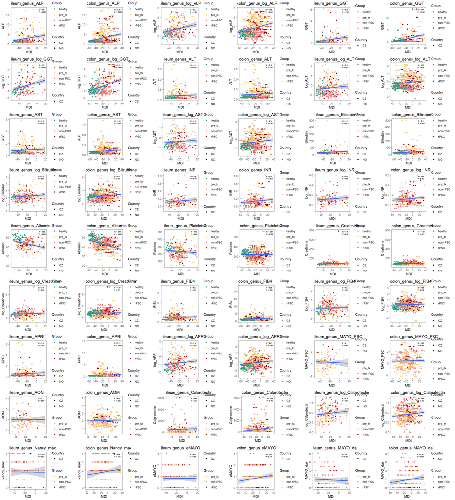

```r
cl_genus
```

## 8.2 Heatmap

**Genus level**

```r
corrs_ileum <- corrs[grepl("ileum_genus",names(corrs))]
corrs_colon <- corrs[grepl("colon_genus",names(corrs))]
```

```r
prepared_list <- prepare_for_heatmap(corrs_ileum,corrs_colon)
p_df_sig_mdi <- prepared_list[[1]]
r_df_mdi <- prepared_list[[2]]
```

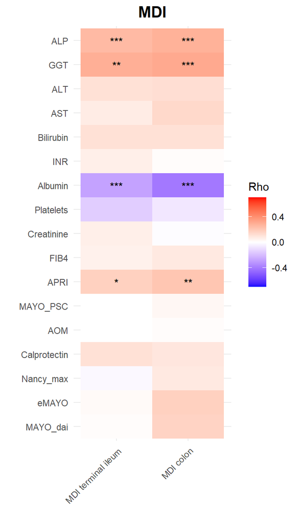

```r
r_df_melt_mdi <- melt(r_df_mdi %>% rownames_to_column("SeqID"))
p_df_melt_mdi <- melt(p_df_sig_mdi %>% rownames_to_column("SeqID"),
                      id.vars = c("SeqID"))

r_df_melt_mdi$SeqID <- factor(r_df_melt_mdi$SeqID,
                              levels=unique(r_df_melt_mdi$SeqID))

p_df_melt_mdi$SeqID <- factor(p_df_melt_mdi$SeqID,
                              levels=unique(p_df_melt_mdi$SeqID))

r_df_melt_mdi$variable <- factor(r_df_melt_mdi$variable,
                              levels=rev(unique(r_df_melt_mdi$variable)))

p_df_melt_mdi$variable <- factor(p_df_melt_mdi$variable,
                              levels=rev(unique(p_df_melt_mdi$variable)))

p_mdi <- ggplot() +
  geom_tile(data=r_df_melt_mdi, aes(SeqID, variable, fill= value))  +
  theme_minimal() +
  scale_fill_gradient2(name = "Rho", low = "blue", mid = "white", high = "red", midpoint = 0,limits = c(-0.7, 0.7)) +
  geom_text(data=p_df_melt_mdi,aes(x=SeqID,y=variable,label=value,vjust=0.6)) +
    theme(axis.text.x = element_text(angle = 45, hjust = 1)) +
  xlab("") + ylab("")  +
  ggtitle("MDI")+
  theme(plot.title = element_text(hjust=0.5,face = "bold",size = 15))

p_mdi
```

# 9 Bacteria and clinical variables

## 9.1 Terminal ileum

```r
level="genus"
```

Aggregation, filtering

```r
# Aggregation
genus_data <- aggregate_taxa(ileum_asv_tab,
                             ileum_taxa_tab,
                             taxonomic_level=level,
                             names=TRUE)
# Filtration
filt_data <- filtering_steps(genus_data[[1]],
                             genus_data[[2]],
                             ileum_metadata,
                             seq_depth_threshold=10000)
```

```
Removing 5 ASV(s)
```

```r
filt_ileum_genus_tab <- filt_data[[1]]
filt_ileum_genus_taxa <- filt_data[[2]]
filt_ileum_metadata_genus <- filt_data[[3]]
```

**PSC effect taxa**

```r
psc_effect_ileum_genus <- read.xlsx(
  "../results/Q1/univariate_analysis/supplements_psc_effect_terminal_ileum.xlsx",
  sheet = "terminal_ileum genus")

psc_taxa <- psc_effect_ileum_genus$SeqID
increased <- psc_effect_ileum_genus$ASV[psc_effect_ileum_genus$log2FoldChange >0]
decreased <- psc_effect_ileum_genus$ASV[psc_effect_ileum_genus$log2FoldChange <0]
```

Preparing datasets

```r
my_table <- filt_ileum_genus_tab %>% column_to_rownames("SeqID")
data_clr <- vegan::decostand(my_table,method = "clr", MARGIN = 2,pseudocount=0.5) %>% as.matrix()

data_clr <- data_clr[psc_taxa,] %>% t() %>% as.data.frame() %>% rownames_to_column("SampleID")

metadata_with_abundances <- data_clr %>% full_join(metadata_ileum,by="SampleID")
```

```r
# significant variables
variables <- c("ALP",
               "APRI",
               "Albumin",
               "Platelets")
```

```r
corrs_ileum <- corrs[grepl("ileum_genus",names(corrs))]
corrs_colon <- corrs[grepl("colon_genus",names(corrs))]
```

```r
prepared_list <- prepare_for_heatmap(corrs_ileum,corrs_colon)
p_df_sig_mdi <- prepared_list[[1]]

variables <- colnames(p_df_sig_mdi)[!apply(p_df_sig_mdi,2,function(x) {
  all(x == "")})]
```

```r
corrs <- list()
clinical_plots <- list()

for (clinical_variable in variables){
  for (taxon in psc_taxa){
    if (grepl("log_",clinical_variable)) {
   metadata_with_abundances[,clinical_variable] <- log(as.numeric(metadata_with_abundances[,gsub("log_","",clinical_variable)]))
  }

  # ILEUM
  # correlation
  corr <- clinical_correlation_abundances(metadata_with_abundances,clinical_variable,taxon,level="genus")
  corrs[[paste0("ileum_genus_",clinical_variable,"_", taxon)]] <- corr
  if (corr$P <0.05){
    p <- clinical_scatter_abundances(corr,metadata_with_abundances,clinical_variable,taxon,level="genus",size = 3)
  clinical_plots[[paste0("ileum_genus_",clinical_variable,"_",taxon)]] <- p
  } else print(corr$P)
  }

}
```

```
[1] 0.68971
[1] 0.5727108
[1] 0.06684104
[1] 0.07115727
[1] 0.6939827
[1] 0.1949693
[1] 0.9010701
[1] 0.8492244
[1] 0.06406532
[1] 0.7152049
[1] 0.2833256
[1] 0.3875891
[1] 0.1593069
[1] 0.1583775
[1] 0.3674669
```

[output cut: 23 more lines]

```r
prepared_list <- subprepare_for_heatmap(corrs,MDI = FALSE)
p_df_sig <- prepared_list[[1]]
r_df <- prepared_list[[2]]
```

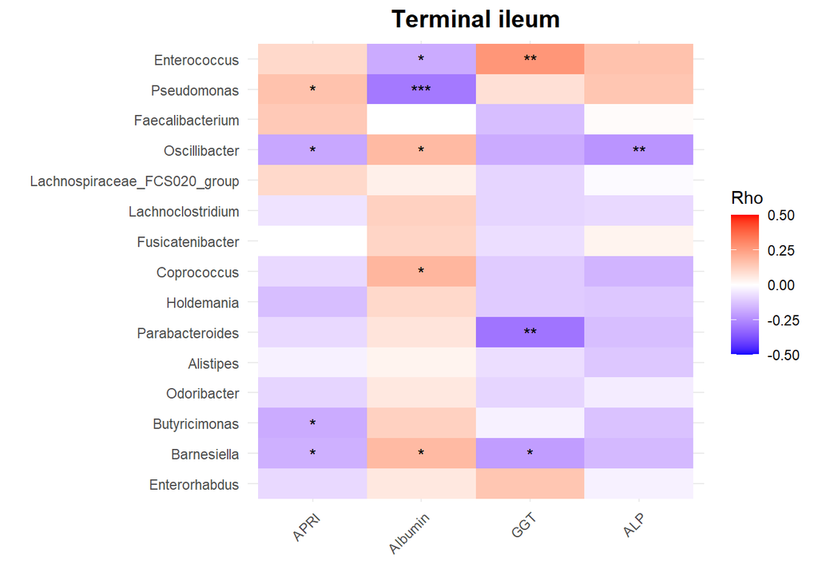

```r
r_df_melt <- melt(r_df %>% rownames_to_column("SeqID"))
p_df_melt <- melt(p_df_sig %>% rownames_to_column("SeqID"),id.vars = c("SeqID"))

r_df_melt$variable <- factor(r_df_melt$variable,
                             levels=rev(unique(r_df_melt$variable)))
p_df_melt$variable <- factor(p_df_melt$variable,
                             levels =rev(unique(p_df_melt$variable)))

r_df_melt$SeqID <- factor(r_df_melt$SeqID, levels = unique(r_df_melt$SeqID))
p_df_melt$SeqID <- factor(p_df_melt$SeqID, levels = unique(p_df_melt$SeqID))

p_ileum <- ggplot() +
  geom_tile(data=r_df_melt, aes(variable, SeqID, fill= value))  +
  theme_minimal() +
  scale_fill_gradient2(name = "Rho", low = "blue", mid = "white", high = "red", midpoint = 0,limits = c(-0.5, 0.5)) +
  geom_text(data=p_df_melt,aes(x=variable,y=SeqID,label=value,vjust=0.6)) +
    theme(axis.text.x = element_text(angle = 45, hjust = 1)) +
  xlab("") + ylab("")  +
  ggtitle("Terminal ileum")+
  theme(plot.title = element_text(hjust=0.5,face = "bold",size = 15))

p_ileum
```

## 9.2 Colon

Aggregation, filtering

```r
genus_data <- aggregate_taxa(colon_asv_tab,
                             colon_taxa_tab,
                             taxonomic_level="Genus",
                             names=TRUE)

# Filtration
filt_data <- filtering_steps(genus_data[[1]],
                             genus_data[[2]],
                             colon_metadata,
                             seq_depth_threshold=10000)
```

```
Removing 10 ASV(s)
```

```r
filt_colon_genus_tab <- filt_data[[1]]
filt_colom_genus_taxa <- filt_data[[2]]
filt_colon_metadata_genus <- filt_data[[3]]
```

```r
psc_effect_colon_genus <- read.xlsx("../results/Q1/univariate_analysis/supplements_psc_effect_colon.xlsx",
                                    sheet = "colon genus")

psc_taxa <- psc_effect_colon_genus$SeqID
increased <- psc_effect_colon_genus$SeqID[psc_effect_colon_genus$log2FoldChange >0]
decreased <- psc_effect_colon_genus$SeqID[psc_effect_colon_genus$log2FoldChange <0]
```

```r
my_table <- filt_colon_genus_tab %>% column_to_rownames("SeqID")
data_clr <- vegan::decostand(my_table,method = "clr", MARGIN = 2,pseudocount=0.5) %>% as.matrix()
data_clr <- data_clr[psc_taxa,] %>% t() %>% as.data.frame() %>% rownames_to_column("SampleID")

metadata_with_abundances <- data_clr %>% full_join(metadata_colon,by="SampleID")
```

```r
variables <- colnames(p_df_sig_mdi)[!apply(p_df_sig_mdi,2,function(x) {
  all(x == "")})]
```

```r
corrs <- list()
clinical_plots <- list()

for (clinical_variable in variables){
  for (taxon in psc_taxa){
    if (grepl("log_",clinical_variable)) {
   metadata_with_abundances[,clinical_variable] <- log(as.numeric(metadata_with_abundances[,gsub("log_","",clinical_variable)]))
  }

  # ILEUM
  # correlation
  corr <- clinical_correlation_abundances(metadata_with_abundances,
                                          clinical_variable,
                                          taxon,level="genus",
                                          rename_p = TRUE)


  if ( (corr$P == "< 0.05") |
       (corr$P == "< 0.01") |
       (corr$P == "< 0.001") |
       corr$P < 0.05){
    p <- clinical_scatter_abundances(corr,
                                     metadata_with_abundances,
                                     clinical_variable,
                                     taxon,
                                     level="genus",
                                     size = 3)

    clinical_plots[[paste0("colon_genus_",clinical_variable,"_",taxon)]] <- p

    # once again, withou renaming
    corr <- clinical_correlation_abundances(metadata_with_abundances,
                                          clinical_variable,
                                          taxon,level="genus")

    corrs[[paste0("colon_genus_",clinical_variable,"_", taxon)]] <- corr

  } else print(corr$P)
}


}
```

```r
clinical_plots_colon <- clinical_plots
corrs_colon <- corrs

prepared_list <- subprepare_for_heatmap(corrs,MDI = FALSE)
p_df_sig <- prepared_list[[1]]
r_df <- prepared_list[[2]]
```

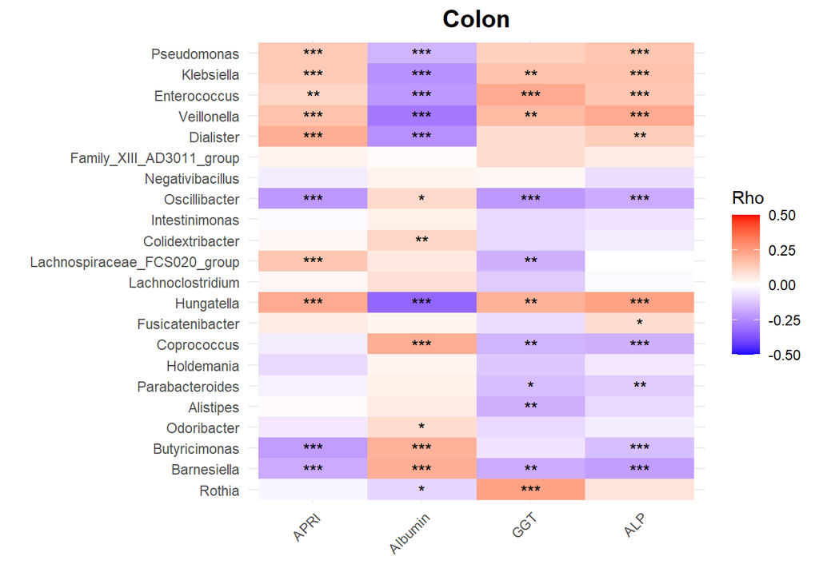

```r
r_df_melt <- melt(r_df %>% rownames_to_column("SeqID"))
p_df_melt <- melt(p_df_sig %>% rownames_to_column("SeqID"),id.vars = c("SeqID"))

r_df_melt$variable <- factor(r_df_melt$variable,
                             levels=rev(unique(r_df_melt$variable)))
p_df_melt$variable <- factor(p_df_melt$variable,
                             levels =rev(unique(p_df_melt$variable)))

r_df_melt$SeqID <- factor(r_df_melt$SeqID, levels = unique(r_df_melt$SeqID))
p_df_melt$SeqID <- factor(p_df_melt$SeqID, levels = unique(p_df_melt$SeqID))

p_colon <- ggplot() +
  geom_tile(data=r_df_melt, aes(variable, SeqID, fill= value))  +
  theme_minimal() +
  scale_fill_gradient2(name = "Rho", low = "blue", mid = "white", high = "red", midpoint = 0,limits = c(-0.5, 0.5)) +
  geom_text(data=p_df_melt,aes(x=variable,y=SeqID,label=value,vjust=0.6)) +
    theme(axis.text.x = element_text(angle = 45, hjust = 1)) +
  xlab("") + ylab("")  +
  ggtitle("Colon")+
  theme(plot.title = element_text(hjust=0.5,face = "bold",size = 15))

p_colon
```

## 9.3 FIGURE 6

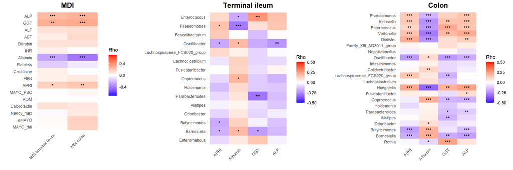

```r
mdi_heatmap <- ggarrange(p_mdi,p_ileum,p_colon,ncol = 3,widths = c(0.7,1,1))
mdi_heatmap
```

# 10 Calprotectin ~ Nancy_max

```r
cor_res <- cor.test(
  metadata_for_boxplots$Calprotectin,
  metadata_for_boxplots$Nancy_max)

cor_res
```

```
    Pearson's product-moment correlation

data:  metadata_for_boxplots$Calprotectin and metadata_for_boxplots$Nancy_max
t = 3.0164, df = 90, p-value = 0.003325
alternative hypothesis: true correlation is not equal to 0
95 percent confidence interval:
 0.1046851 0.4781488
sample estimates:
      cor
0.3030057
```

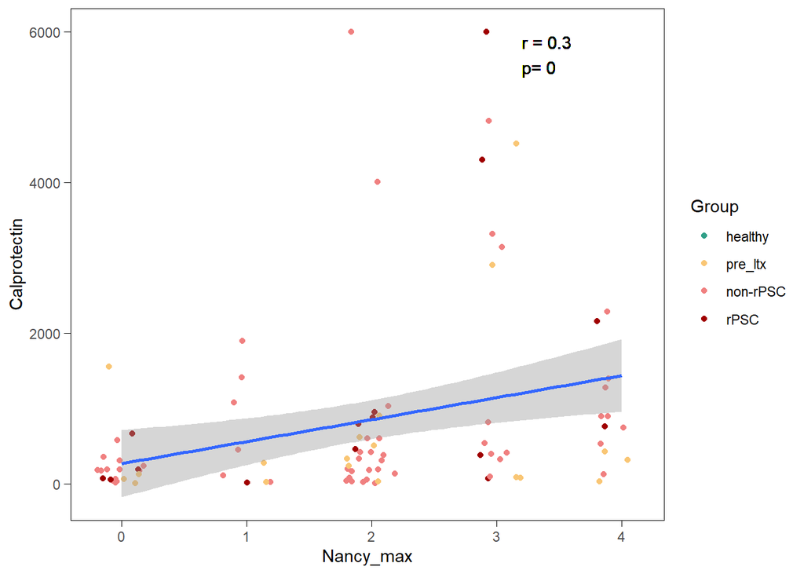

```r
p_1 <- ggplot(metadata_for_boxplots) +
  geom_jitter(
      aes(x=Nancy_max, y=Calprotectin, color=Group),
      height = 0,width = 0.2) +
  geom_text(aes(x=3.2, y=5700),
            label=gsub("\\\\n", "\n", labels),hjust = 0) +
  geom_smooth(aes(x=Nancy_max, y=Calprotectin),
              method=lm, se=TRUE) +
  theme_minimal() +
  theme(panel.border = element_rect(color = "black", fill = NA, size = 0),
        axis.ticks.x = element_line(size=0.3,color = "black"),
        axis.ticks.y = element_line(size=0.3,color="black"),
        axis.ticks.length = unit(4,"pt"),
        panel.grid = element_blank()) +
  scale_color_manual(values=c("#309f87","#f9c675","#F08080","#A00000"))

p_1
```

# 11 Calprotectin ~ ALP

```r
cor_res <- cor.test(
  metadata_for_boxplots$Calprotectin,
  metadata_for_boxplots$ALP)

cor_res
```

```
    Pearson's product-moment correlation

data:  metadata_for_boxplots$Calprotectin and metadata_for_boxplots$ALP
t = -0.45614, df = 236, p-value = 0.6487
alternative hypothesis: true correlation is not equal to 0
95 percent confidence interval:
 -0.15625130  0.09785193
sample estimates:
        cor
-0.02967918
```

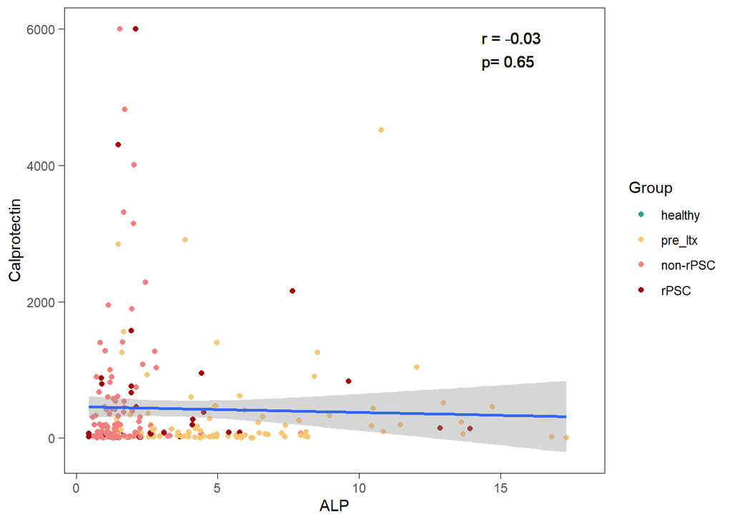

```r
p_2 <- ggplot(metadata_for_boxplots) +
    geom_jitter(aes(x=ALP, y=Calprotectin, color=Group),height = 0,width = 0) +
  geom_text(aes(x=14.34, y=5700),
              label=gsub("\\\\n", "\n", labels),hjust = 0) +
    geom_smooth(aes(x=ALP, y=Calprotectin),method=lm, se=TRUE) +
    theme_minimal() +
    theme(panel.border = element_rect(color = "black", fill = NA, size = 0),
          axis.ticks.x = element_line(size=0.3,color = "black"),
          axis.ticks.y = element_line(size=0.3,color="black"),
          axis.ticks.length = unit(4,"pt"),
          panel.grid = element_blank()) +
  scale_color_manual(values=c("#309f87","#f9c675","#F08080","#A00000"))

p_2
```

# 12 Calprotectin ~ GGT

```r
cor_res <- cor.test(
  metadata_for_boxplots$Calprotectin,
  metadata_for_boxplots$GGT)

cor_res
```

```
    Pearson's product-moment correlation

data:  metadata_for_boxplots$Calprotectin and metadata_for_boxplots$GGT
t = -0.17189, df = 108, p-value = 0.8638
alternative hypothesis: true correlation is not equal to 0
95 percent confidence interval:
 -0.2031507  0.1712334
sample estimates:
        cor
-0.01653834
```

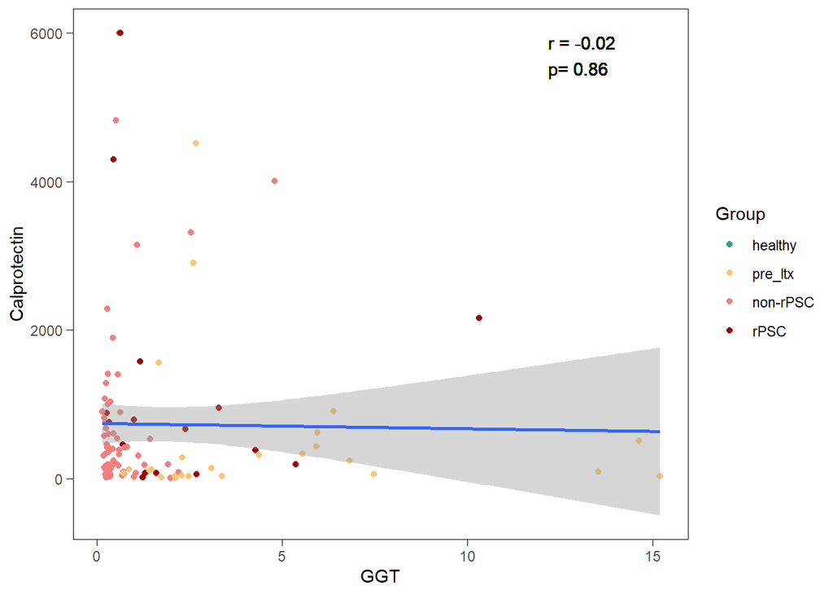

```r
p_3 <- ggplot(metadata_for_boxplots) +
  geom_jitter(aes(x=GGT, y=Calprotectin, color=Group),
                height = 0,width = 0) +
  geom_text(aes(x=12.18, y=5700),
            label=gsub("\\\\n", "\n", labels),hjust = 0) +
  geom_smooth(aes(x=GGT, y=Calprotectin),method=lm, se=TRUE) +
  theme_minimal() +
  theme(panel.border = element_rect(color = "black", fill = NA, size = 0),
        axis.ticks.x = element_line(size=0.3,color = "black"),
        axis.ticks.y = element_line(size=0.3,color="black"),
        axis.ticks.length = unit(4,"pt"),
        panel.grid = element_blank()) +
  scale_color_manual(values=c("#309f87","#f9c675","#F08080","#A00000"))

p_3
```

# 13 Nancy_max ~ ALP

```r
cor_res <- cor.test(
  metadata_for_boxplots$ALP,
  metadata_for_boxplots$Nancy_max)

cor_res
```

```
    Pearson's product-moment correlation

data:  metadata_for_boxplots$ALP and metadata_for_boxplots$Nancy_max
t = -0.5031, df = 111, p-value = 0.6159
alternative hypothesis: true correlation is not equal to 0
95 percent confidence interval:
 -0.2303974  0.1382504
sample estimates:
        cor
-0.04769762
```

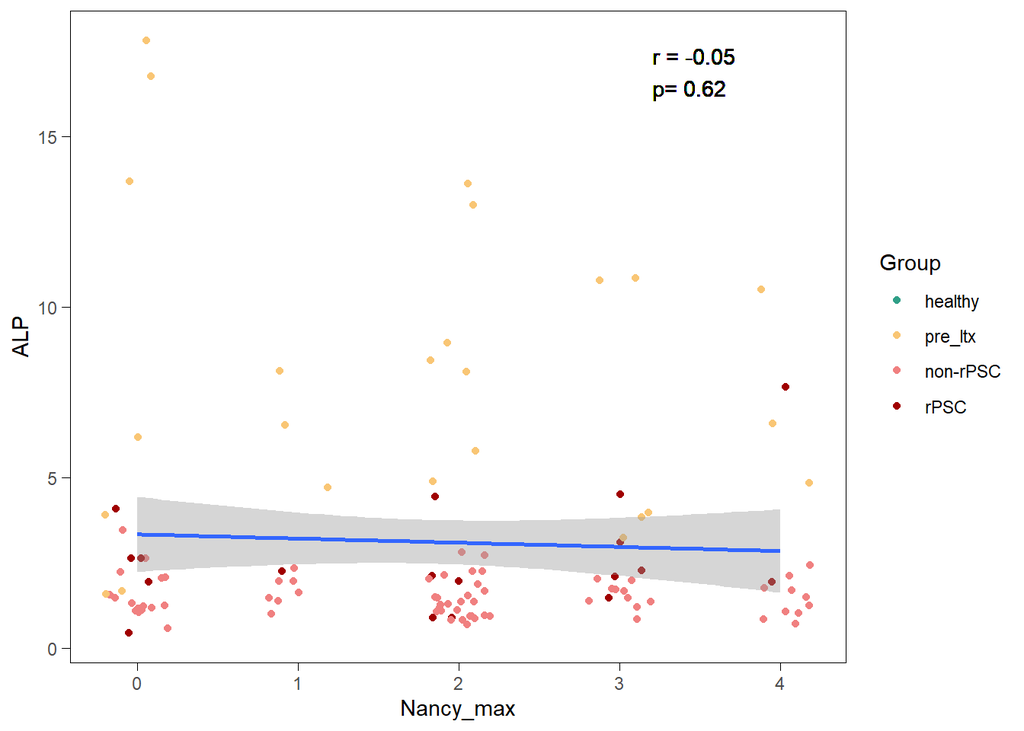

```r
p_4 <- ggplot(metadata_for_boxplots) +
  geom_jitter(aes(x=Nancy_max, y=ALP, color=Group),
                height = 0,width = 0.2) +
  geom_text(aes(x=3.2, y=16.9),
              label=gsub("\\\\n", "\n", labels),hjust = 0) +
    geom_smooth(aes(x=Nancy_max, y=ALP),method=lm, se=TRUE) +
    theme_minimal() +
    theme(panel.border = element_rect(color = "black", fill = NA, size = 0),
          axis.ticks.x = element_line(size=0.3,color = "black"),
          axis.ticks.y = element_line(size=0.3,color="black"),
          axis.ticks.length = unit(4,"pt"),
          panel.grid = element_blank()) +
  scale_color_manual(values=c("#309f87","#f9c675","#F08080","#A00000"))

p_4
```

# 14 Nancy_max ~ GGT

```r
cor_res <- cor.test(metadata_for_boxplots$GGT,
                    metadata_for_boxplots$Nancy_max)
cor_res
```

```
    Pearson's product-moment correlation

data:  metadata_for_boxplots$GGT and metadata_for_boxplots$Nancy_max
t = 0.52563, df = 110, p-value = 0.6002
alternative hypothesis: true correlation is not equal to 0
95 percent confidence interval:
 -0.1367723  0.2334414
sample estimates:
      cor
0.0500538
```

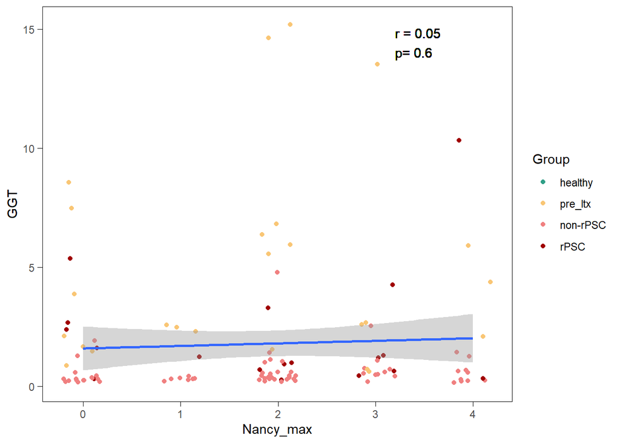

```r
p_5 <- ggplot(metadata_for_boxplots) +
    geom_jitter(aes(x=Nancy_max, y=GGT, color=Group),height = 0,width = 0.2) +
  geom_text(aes(x=3.2, y=14.45),
              label=gsub("\\\\n", "\n", labels),hjust = 0) +
    geom_smooth(aes(x=Nancy_max, y=GGT),method=lm, se=TRUE) +
    theme_minimal() +
    theme(panel.border = element_rect(color = "black", fill = NA, size = 0),
          axis.ticks.x = element_line(size=0.3,color = "black"),
          axis.ticks.y = element_line(size=0.3,color="black"),
          axis.ticks.length = unit(4,"pt"),
          panel.grid = element_blank()) +
  scale_color_manual(values=c("#309f87","#f9c675","#F08080","#A00000"))

p_5
```

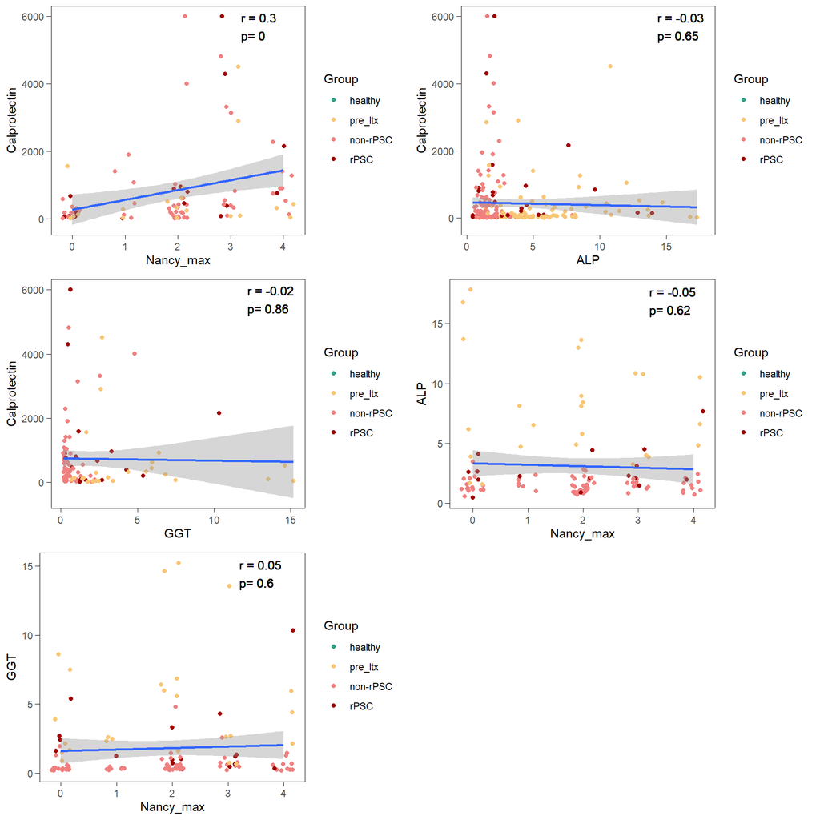

```r
p <- ggarrange(plotlist=list(p_1,p_2,p_3,p_4,p_5),ncol=2,nrow=3)
p
```

```r
pdf("../figures/clinical/calprotectin_nancymax.pdf",width = 10,height = 10)
p
dev.off()
```